# bivalency_analysis

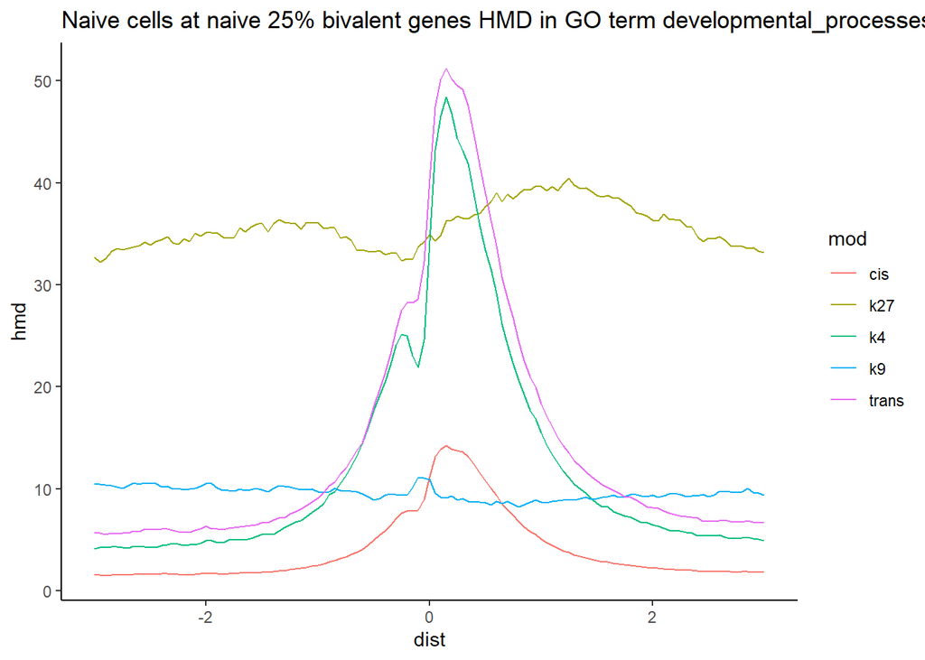

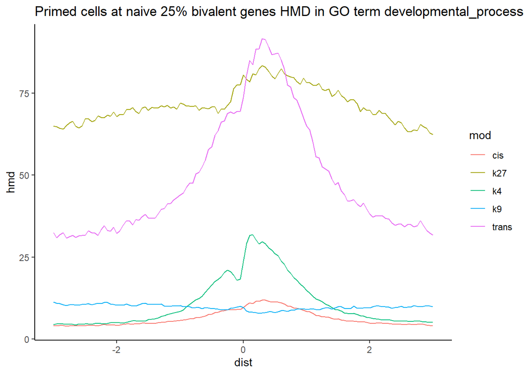

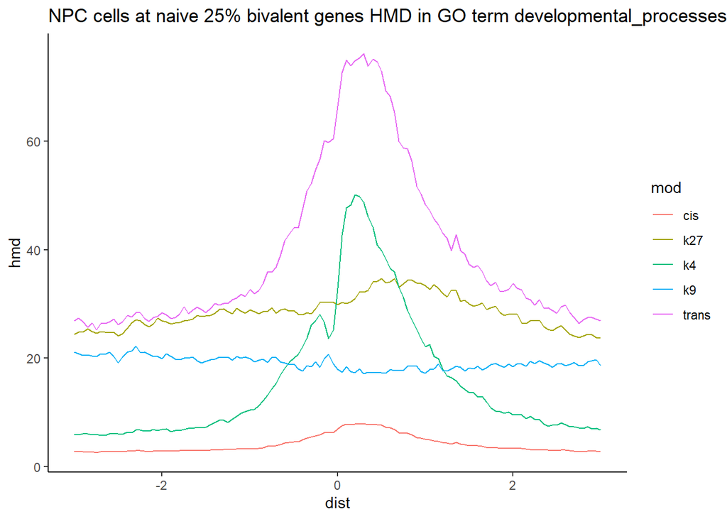

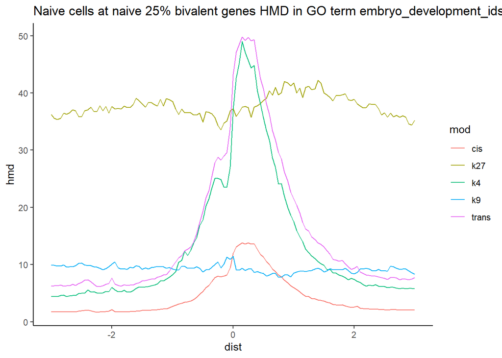

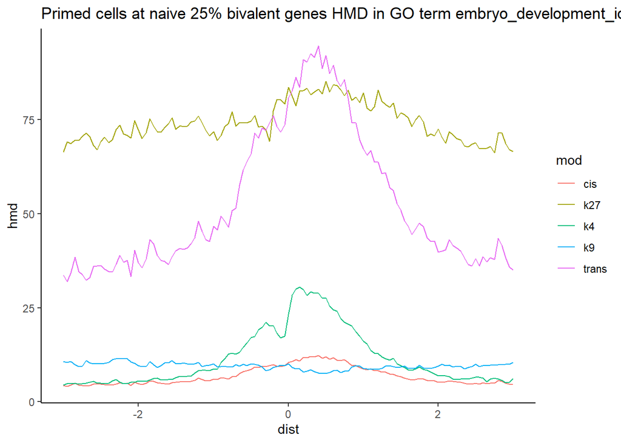

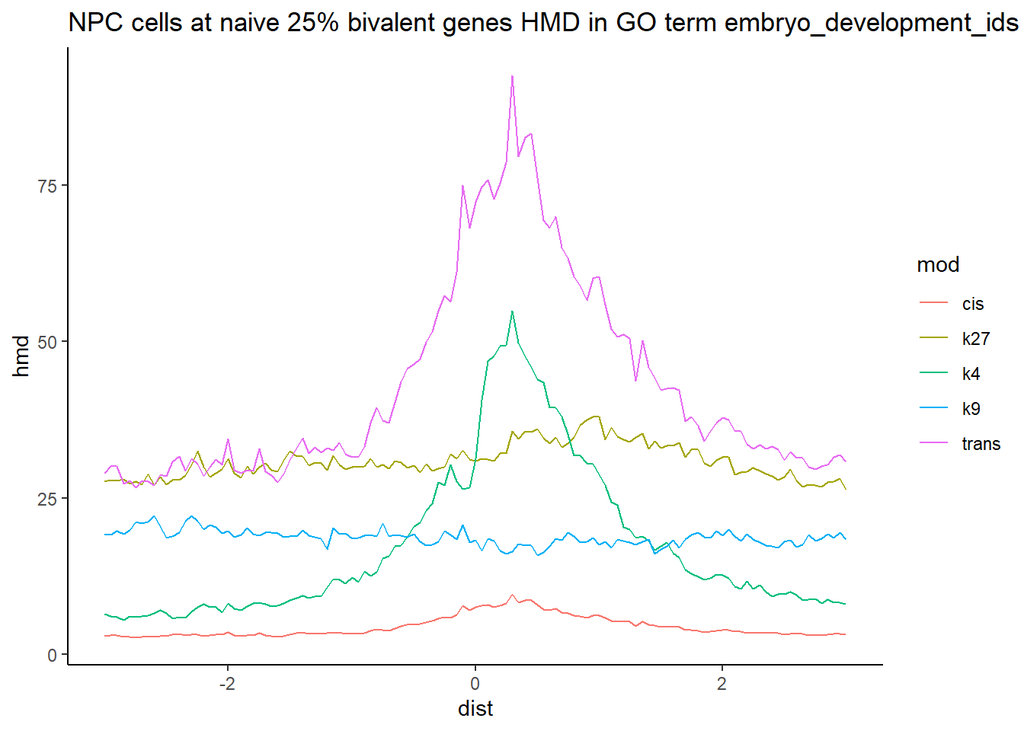

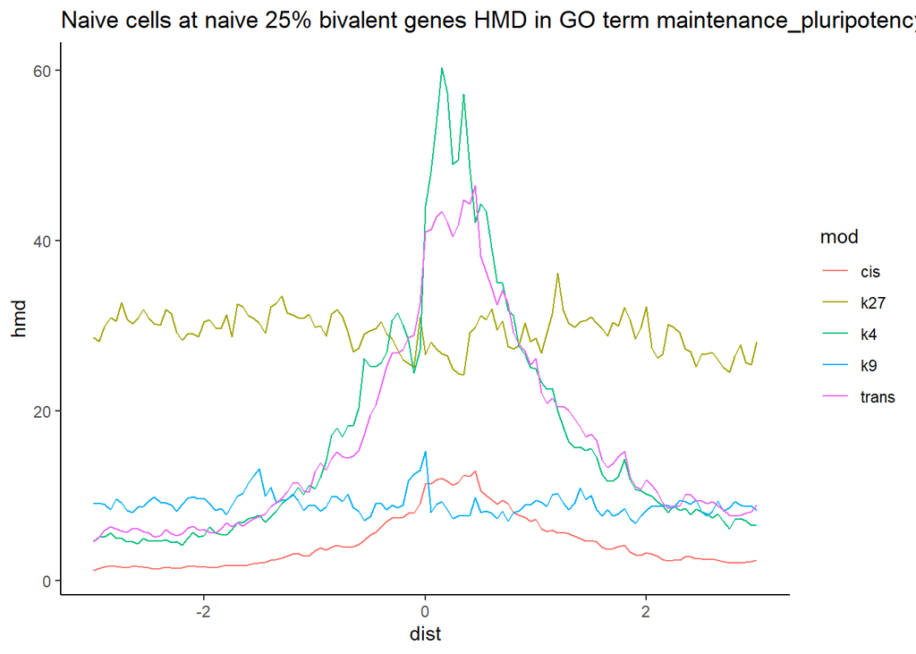

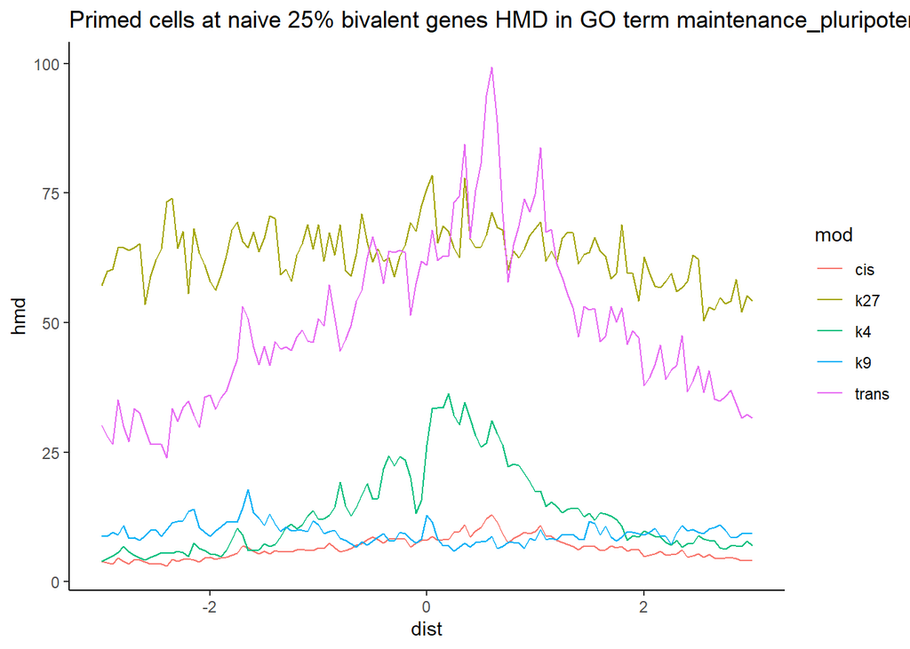

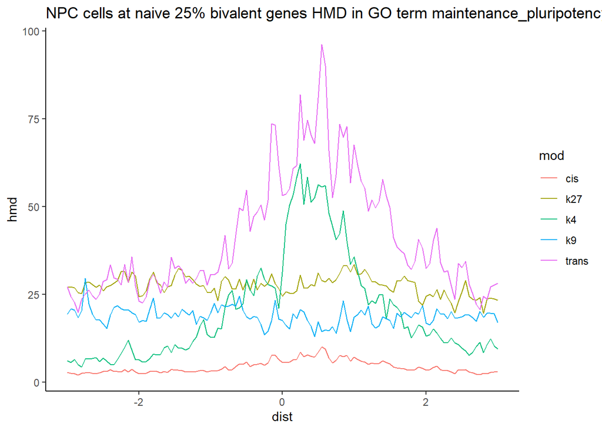

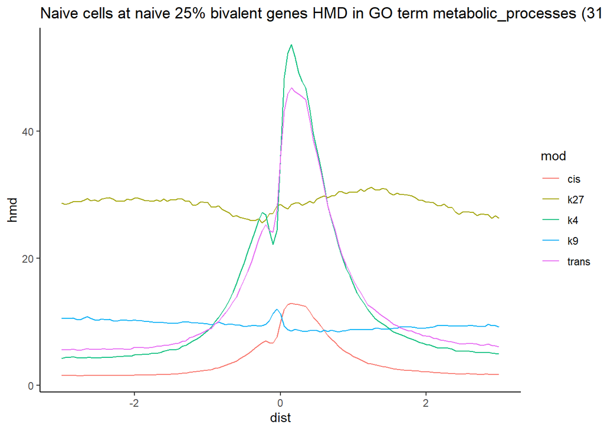

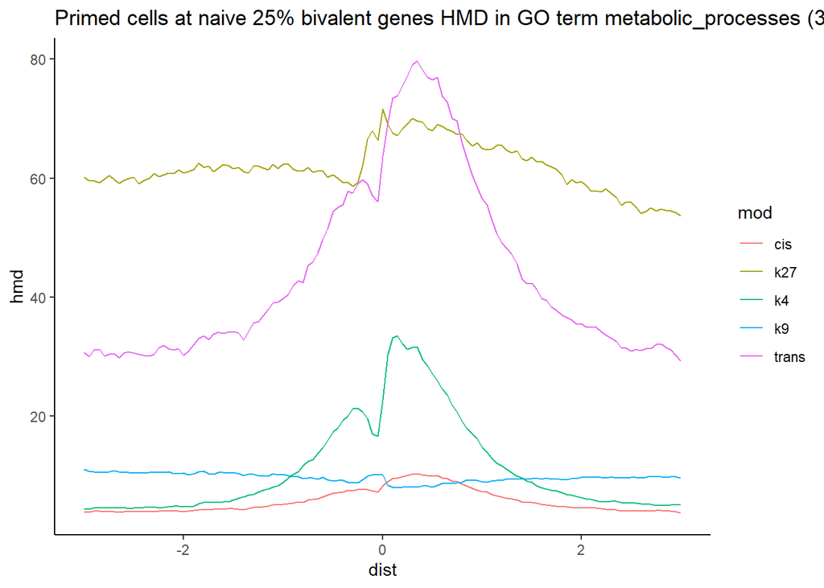

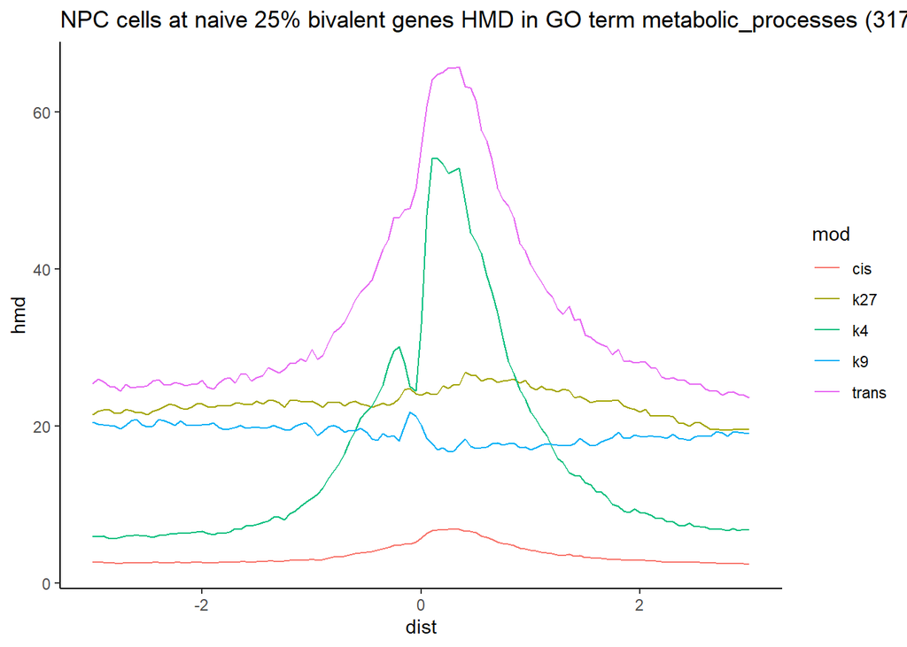

[6 more figures not shown]

```r
for (go_term in names(go_ids))
{
  overlapgenes = (refseq_ensembl_external_go %>% filter(go_id %in% go_ids[[go_term]] & refseq_id %in% bivalent_genes_25[["naive"]]))$refseq_id

  count_genes = length(overlapgenes)

  metagene_plot(metagene(naive, tss_range, overlapgenes), title = paste0("Naive cells at naive 25% bivalent genes HMD in GO term ", go_term, " (", count_genes, " genes)"))
  metagene_plot(metagene(primed, tss_range, overlapgenes), title = paste0("Primed cells at naive 25% bivalent genes HMD in GO term ", go_term, " (", count_genes, " genes)"))
  metagene_plot(metagene(npc, tss_range, overlapgenes), title = paste0("NPC cells at naive 25% bivalent genes HMD in GO term ", go_term, " (", count_genes, " genes)"))
}
```

```r
rm(count_genes)
```

Across the different GO term classes, bivalent genes remain bivalent.

# RNA-seq First-Pass Analysis

We have three RNA-seq datasets, which we have already aligned against the Refseq cDNA for mm10 using Kallisto and loaded into Sleuth. These are contained in sleuth_objs.

First, we will look at the data by PCA.

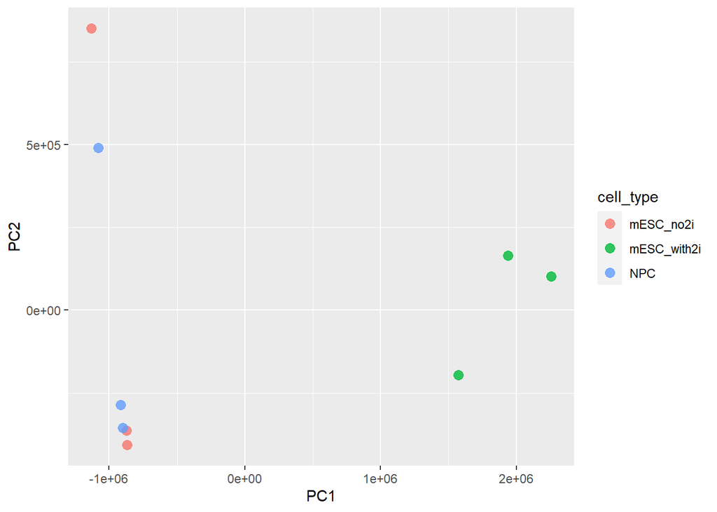

```r
plot_pca(sleuth_objs$all, color_by = "cell_type")
```

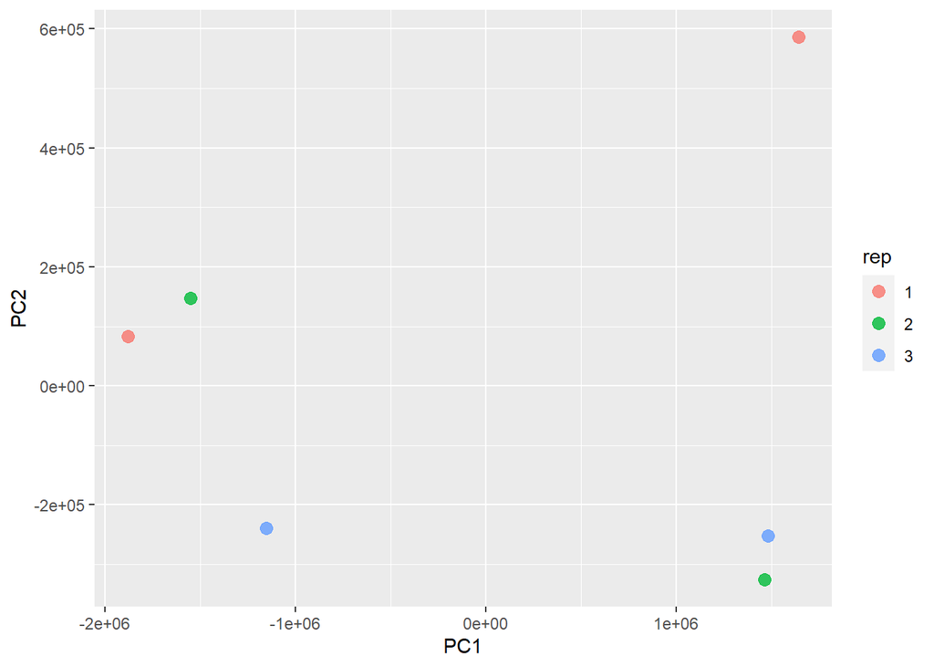

```r
plot_pca(sleuth_objs$naive_npc, color_by = "rep")
```

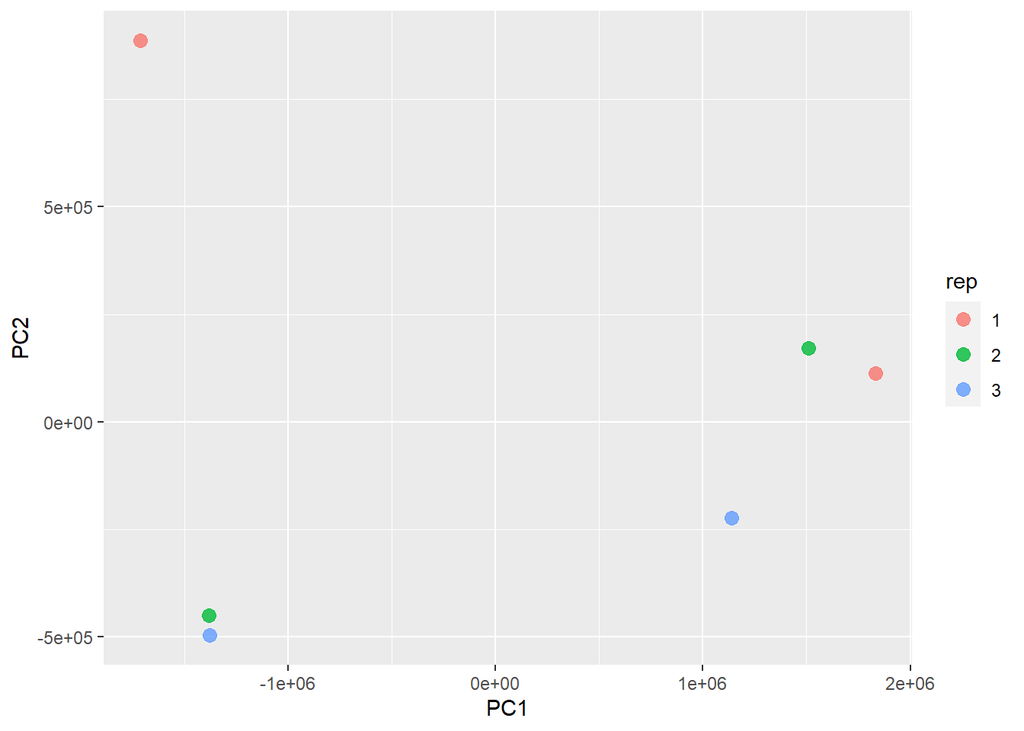

```r
plot_pca(sleuth_objs$naive_primed, color_by = "rep")
```

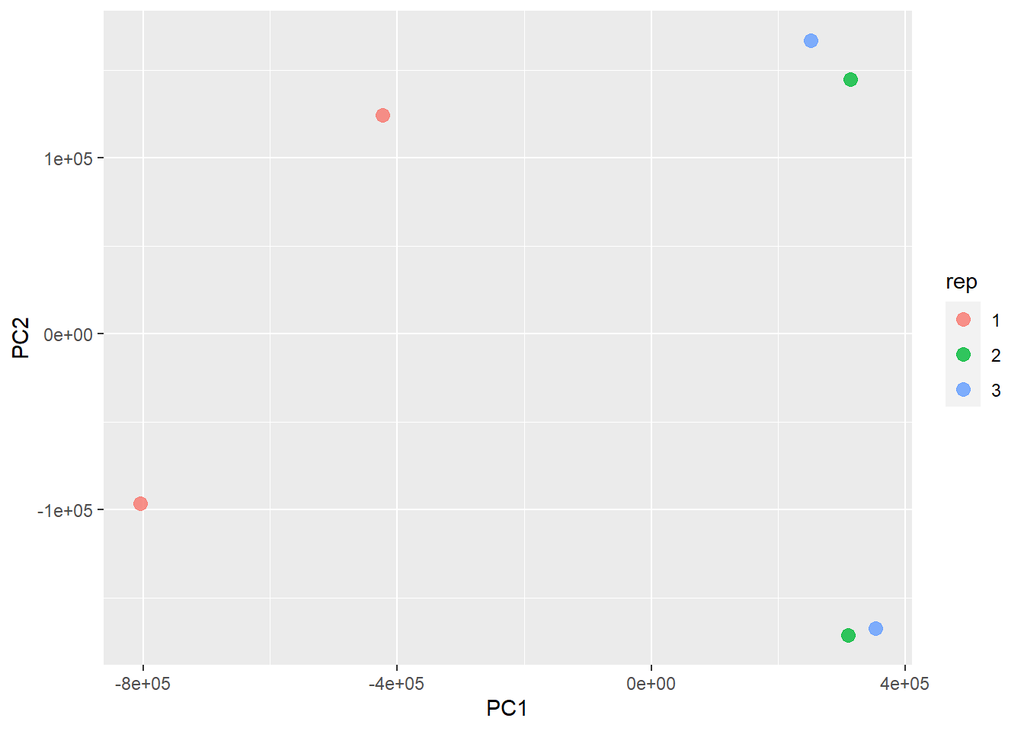

```r
plot_pca(sleuth_objs$primed_npc, color_by = "rep")
```

PCA looks fine, samples separate as expected without huge batch effects except with primed to NPC. We’ll correct for replicate there but will otherwise just use a naive comparison.

First, we will compare naive to NPC, then naive to primed, then finally primed to NPC.

```r
if (!file.exists("rdata/sleuth_analysis.RData")){
  sleuth_table_gene = list()

  sleuth_objs$naive_npc = sleuth_fit(sleuth_objs$naive_npc, ~1, 'naive')
  sleuth_objs$naive_npc = sleuth_fit(sleuth_objs$naive_npc, ~cell_type, 'cell_type')
  sleuth_objs$naive_npc = sleuth_lrt(sleuth_objs$naive_npc, 'naive', 'cell_type')

  sleuth_table_gene[["naive_npc"]] = sleuth_results(sleuth_objs$naive_npc, 'naive:cell_type', 'lrt', show_all = FALSE, pval_aggregate = FALSE) %>% mutate(refseq_id = str_replace(target_id, "([A-Za-z0-9_]*)\\.[0-9]*", "\\1"))

  sleuth_objs$naive_primed = sleuth_fit(sleuth_objs$naive_primed, ~1, 'naive')
  sleuth_objs$naive_primed = sleuth_fit(sleuth_objs$naive_primed, ~cell_type, 'cell_type')
  sleuth_objs$naive_primed = sleuth_lrt(sleuth_objs$naive_primed, 'naive', 'cell_type')

  sleuth_table_gene[["naive_primed"]] = sleuth_results(sleuth_objs$naive_primed, 'naive:cell_type', 'lrt', show_all = FALSE, pval_aggregate = FALSE) %>% mutate(refseq_id = str_replace(target_id, "([A-Za-z0-9_]*)\\.[0-9]*", "\\1"))

  sleuth_objs$primed_npc = sleuth_fit(sleuth_objs$primed_npc, ~1, 'naive')
  sleuth_objs$primed_npc = sleuth_fit(sleuth_objs$primed_npc, ~rep, 'rep')
  sleuth_objs$primed_npc = sleuth_fit(sleuth_objs$primed_npc, ~cell_type, 'cell_type')
  sleuth_objs$primed_npc = sleuth_fit(sleuth_objs$primed_npc, ~rep+cell_type, 'full')
  sleuth_objs$primed_npc = sleuth_lrt(sleuth_objs$primed_npc, 'naive', 'cell_type')
  sleuth_objs$primed_npc = sleuth_lrt(sleuth_objs$primed_npc, 'rep', 'full')

  sleuth_table_gene[["primed_npc"]] = sleuth_results(sleuth_objs$primed_npc, 'rep:full', 'lrt', show_all = FALSE, pval_aggregate = FALSE) %>% mutate(refseq_id = str_replace(target_id, "([A-Za-z0-9_]*)\\.[0-9]*", "\\1"))

  save.image("rdata/sleuth_analysis.RData")
} else{
  load("rdata/sleuth_analysis.RData")
}
```

We see that there are several thousand genes that are differentially expressed in all these conditions: 19450/51998 from naive to NPC, 17835/50800 from naive to primed, and 9908/50126 from primed to NPC.

We also want to be able to get our average gene expression for each gene.

```r
gene_expression = sleuth_objs$all$obs_norm %>% separate(sample, c("cell_type", "rep"), sep = "_RNA_rep") %>% group_by(target_id, cell_type) %>% select(target_id, cell_type, tpm) %>% summarize(across(.fns = mean)) %>% ungroup %>% spread(key = cell_type, value = tpm)

gene_expression = gene_expression %>% data.frame %>% mutate(refseq_id = str_replace(target_id, "([A-Za-z0-9_]*)\\.[0-9]*", "\\1")) %>% select(target_id, refseq_id, naive = mESC_with2i, primed = mESC_no2i, npc = NPC)
```

We must also identify upregulated and downregulated genes

```r
upregulated_genes = list()
downregulated_genes = list()
nonregulated_genes = list()

upregulated_genes$naive_npc = (sleuth_table_gene$naive_npc %>% filter(qval <= 0.05) %>% inner_join(gene_expression, by = "refseq_id") %>% filter(npc > naive))$refseq_id
downregulated_genes$naive_npc = (sleuth_table_gene$naive_npc %>% filter(qval <= 0.05) %>% inner_join(gene_expression, by = "refseq_id") %>% filter(npc < naive))$refseq_id
nonregulated_genes$naive_npc = (sleuth_table_gene$naive_npc %>% filter(qval > 0.05))$refseq_id

upregulated_genes$naive_primed = (sleuth_table_gene$naive_primed %>% filter(qval <= 0.05) %>% inner_join(gene_expression, by = "refseq_id") %>% filter(primed > naive))$refseq_id
downregulated_genes$naive_primed = (sleuth_table_gene$naive_primed %>% filter(qval <= 0.05) %>% inner_join(gene_expression, by = "refseq_id") %>% filter(primed < naive))$refseq_id
nonregulated_genes$naive_primed = (sleuth_table_gene$naive_primed %>% filter(qval > 0.05))$refseq_id

upregulated_genes$primed_npc = (sleuth_table_gene$primed_npc %>% filter(qval <= 0.05) %>% inner_join(gene_expression, by = "refseq_id") %>% filter(npc > primed))$refseq_id
downregulated_genes$primed_npc = (sleuth_table_gene$primed_npc %>% filter(qval <= 0.05) %>% inner_join(gene_expression, by = "refseq_id") %>% filter(npc < primed))$refseq_id
nonregulated_genes$primed_npc = (sleuth_table_gene$primed_npc %>% filter(qval > 0.05))$refseq_id
```

# Integrating RNA-seq and HMD Metagene Analysis

Having the above gene expression matrix, I want to examine the way in which gene expression changes across these different datasets from naive to NPC.

## Violin plots of gene expression

First thing to do is to get the gene expression of the genes overall.

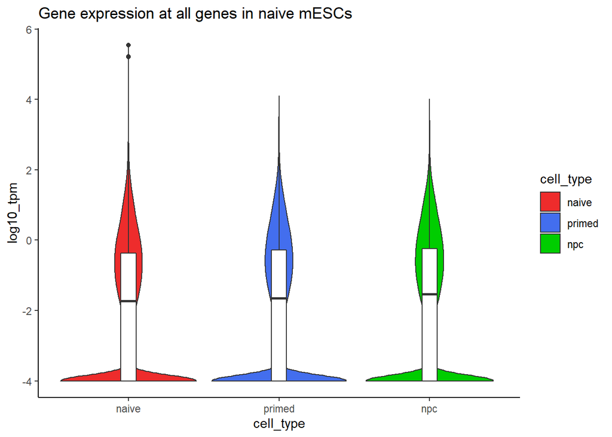

```r
violin_df = gene_expression %>% select(refseq_id:npc) %>% mutate(across(.cols = naive:npc, .fns = ~log10(.+.0001))) %>% gather(key = "cell_type", value = "log10_tpm", -refseq_id)
violin_df$cell_type = factor(violin_df$cell_type, levels = c('naive', 'primed', 'npc'), ordered = TRUE)

violin_plt = ggplot(data = violin_df, aes(x = cell_type, y = log10_tpm, fill = cell_type)) + geom_violin() +  stat_summary(fun=mean, geom="point", shape=23, size=2, fill = "black") + theme_classic() + geom_boxplot(fill = "white", width = 0.1) + scale_fill_manual(values = c("firebrick2", "royalblue2", "green3")) + labs(title = "Gene expression at all genes in naive mESCs")
print(violin_plt)
```

```r
rm(violin_df, violin_plt)
```

Next, we plot gene expression of bivalent genes in naive cells.

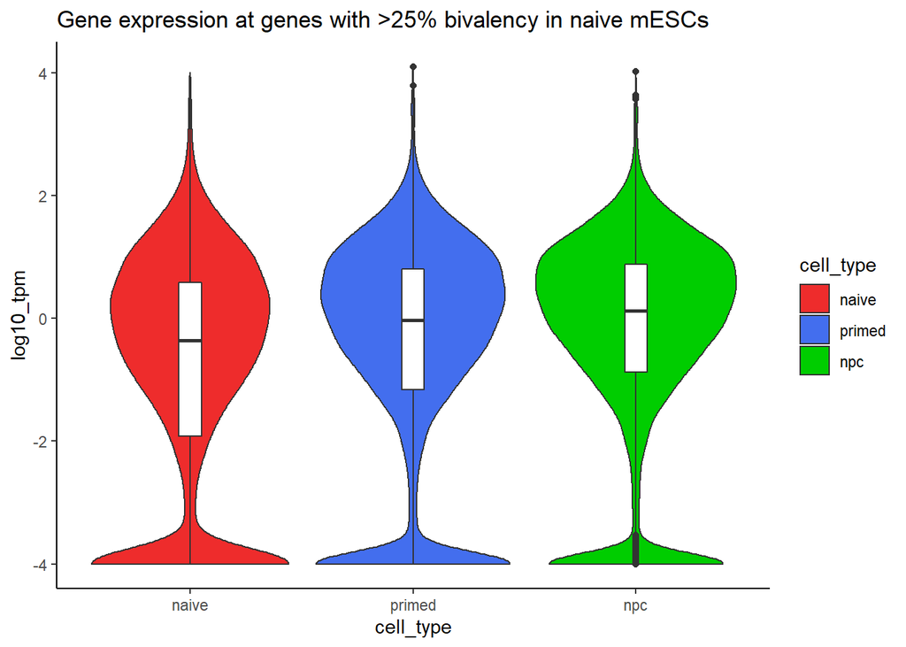

```r
violin_df = gene_expression %>% filter(refseq_id %in% bivalent_genes_25$naive) %>% select(refseq_id:npc) %>% mutate(across(.cols = naive:npc, .fns = ~log10(.+.0001))) %>% gather(key = "cell_type", value = "log10_tpm", -refseq_id)
violin_df$cell_type = factor(violin_df$cell_type, levels = c('naive', 'primed', 'npc'), ordered = TRUE)

violin_plt = ggplot(data = violin_df, aes(x = cell_type, y = log10_tpm, fill = cell_type)) + geom_violin() +  stat_summary(fun=mean, geom="point", shape=23, size=2, fill = "black") + theme_classic() + geom_boxplot(fill = "white", width = 0.1) + scale_fill_manual(values = c("firebrick2", "royalblue2", "green3")) + labs(title = "Gene expression at genes with >25% bivalency in naive mESCs")
print(violin_plt)
```

```r
rm(violin_df, violin_plt)
```

We see only subtle changes at best. Let us now section by K27 or K4 dominance.

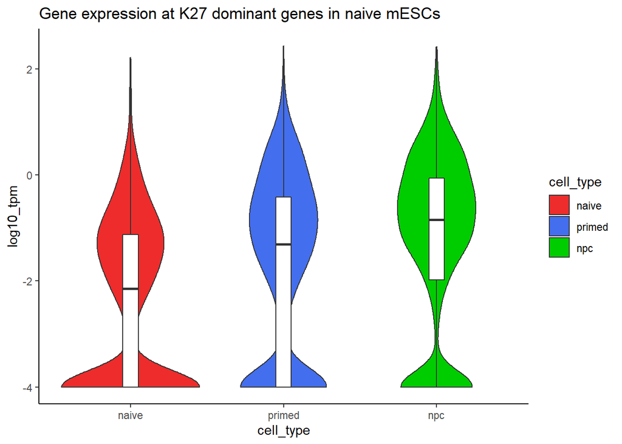

```r
violin_df = gene_expression %>% filter(refseq_id %in% naive_dominance$k27) %>% select(refseq_id:npc) %>% mutate(across(.cols = naive:npc, .fns = ~log10(.+.0001))) %>% gather(key = "cell_type", value = "log10_tpm", -refseq_id)
violin_df$cell_type = factor(violin_df$cell_type, levels = c('naive', 'primed', 'npc'), ordered = TRUE)

violin_plt = ggplot(data = violin_df, aes(x = cell_type, y = log10_tpm, fill = cell_type)) + geom_violin() +  stat_summary(fun=mean, geom="point", shape=23, size=2, fill = "black") + theme_classic() + geom_boxplot(fill = "white", width = 0.1) + scale_fill_manual(values = c("firebrick2", "royalblue2", "green3")) + labs(title = "Gene expression at K27 dominant genes in naive mESCs")
print(violin_plt)
```

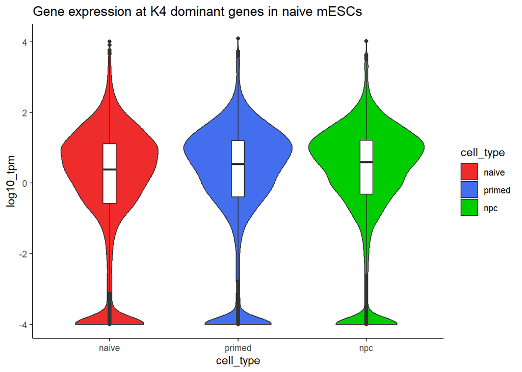

```r
rm(violin_df, violin_plt)

violin_df = gene_expression %>% filter(refseq_id %in% naive_dominance$k4) %>% select(refseq_id:npc) %>% mutate(across(.cols = naive:npc, .fns = ~log10(.+.0001))) %>% gather(key = "cell_type", value = "log10_tpm", -refseq_id)
violin_df$cell_type = factor(violin_df$cell_type, levels = c('naive', 'primed', 'npc'), ordered = TRUE)

violin_plt = ggplot(data = violin_df, aes(x = cell_type, y = log10_tpm, fill = cell_type)) + geom_violin() +  stat_summary(fun=mean, geom="point", shape=23, size=2, fill = "black") + theme_classic() + geom_boxplot(fill = "white", width = 0.1) + scale_fill_manual(values = c("firebrick2", "royalblue2", "green3")) + labs(title = "Gene expression at K4 dominant genes in naive mESCs")
print(violin_plt)
```

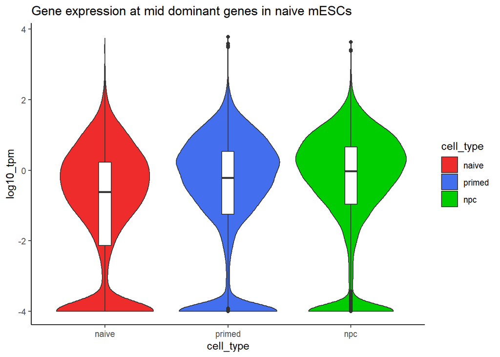

```r
rm(violin_df, violin_plt)

violin_df = gene_expression %>% filter(refseq_id %in% naive_dominance$mid) %>% select(refseq_id:npc) %>% mutate(across(.cols = naive:npc, .fns = ~log10(.+.0001))) %>% gather(key = "cell_type", value = "log10_tpm", -refseq_id)
violin_df$cell_type = factor(violin_df$cell_type, levels = c('naive', 'primed', 'npc'), ordered = TRUE)

violin_plt = ggplot(data = violin_df, aes(x = cell_type, y = log10_tpm, fill = cell_type)) + geom_violin() +  stat_summary(fun=mean, geom="point", shape=23, size=2, fill = "black") + theme_classic() + geom_boxplot(fill = "white", width = 0.1) + scale_fill_manual(values = c("firebrick2", "royalblue2", "green3")) + labs(title = "Gene expression at mid dominant genes in naive mESCs")
print(violin_plt)
```

```r
rm(violin_df, violin_plt)
```

The other thing that we can do here is to bin the naive mESC bivalent genes by gene expression, then track those subsets of genes across the differentiation pathway.

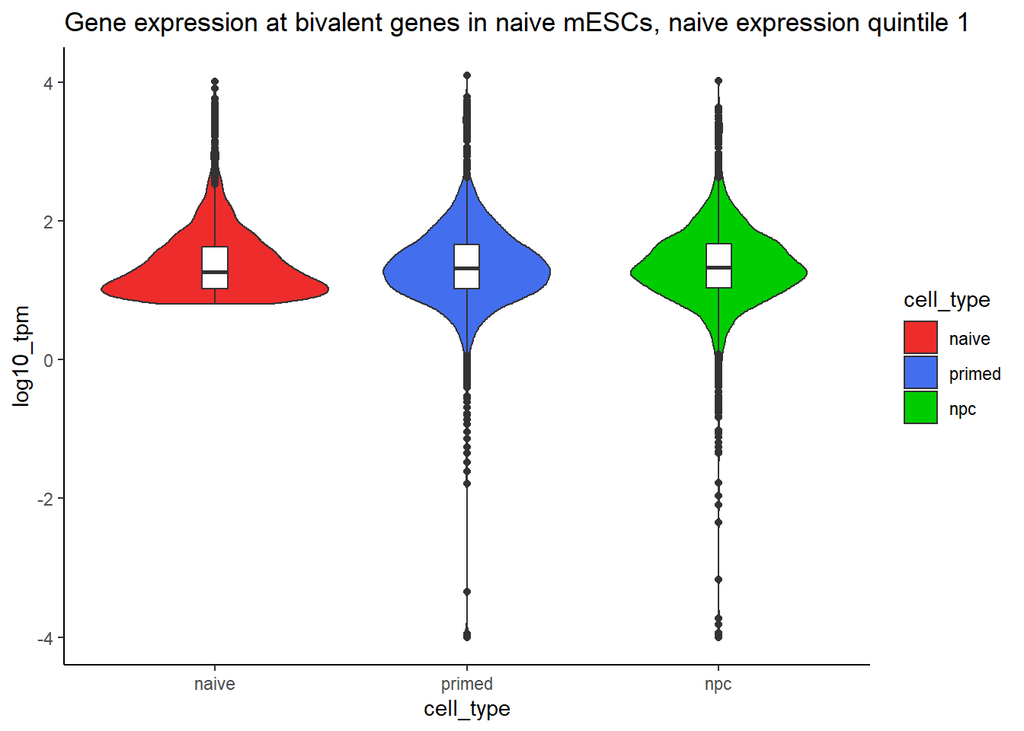

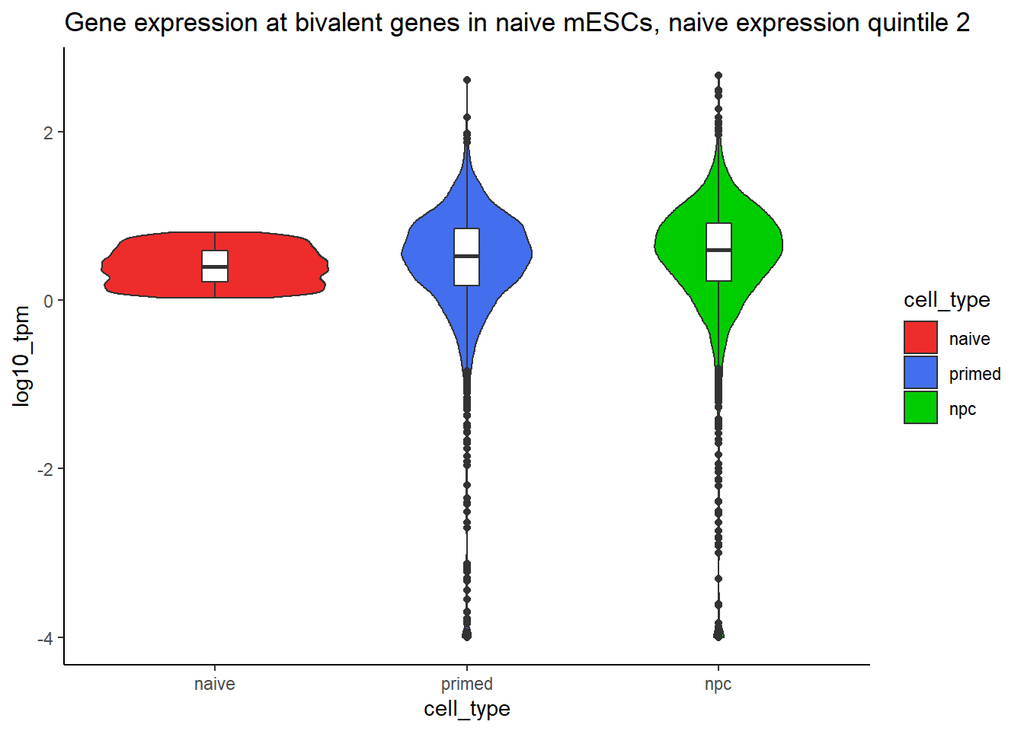

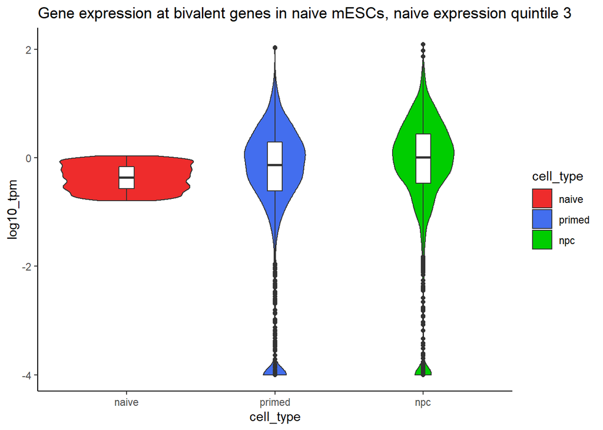

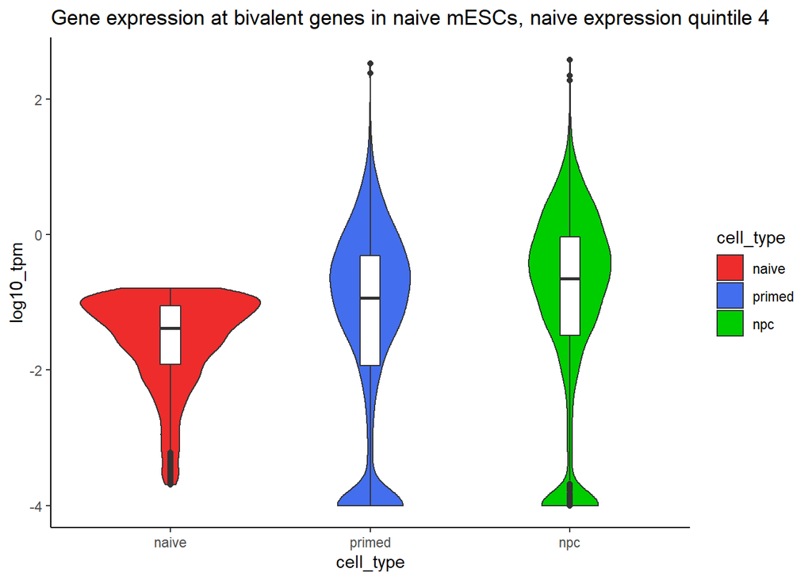

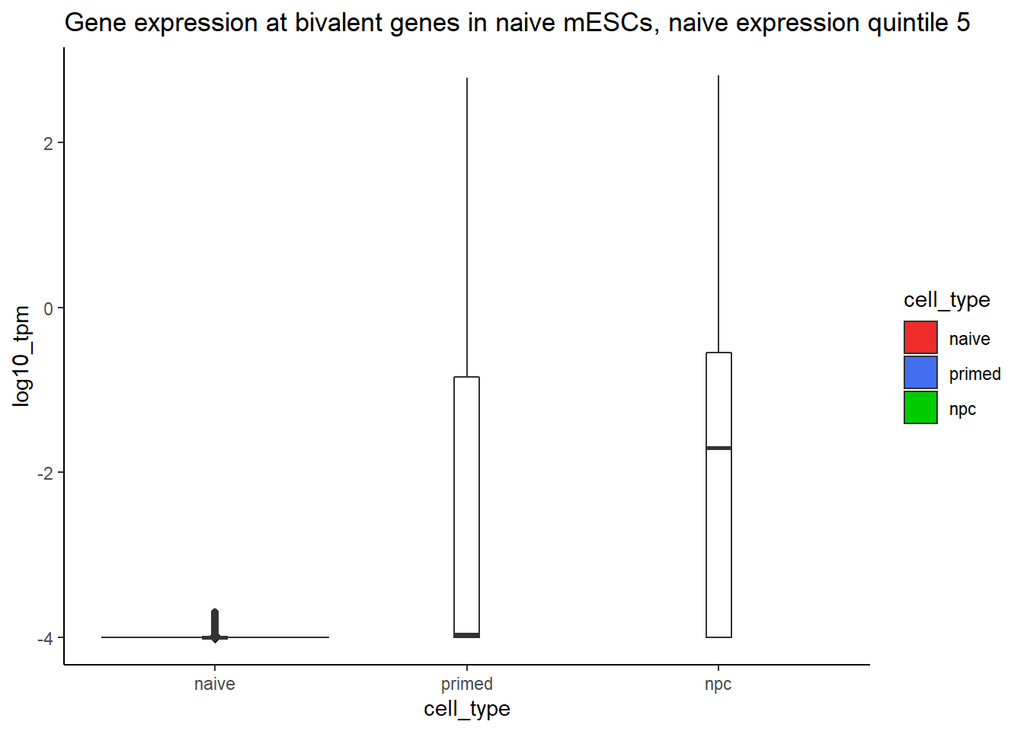

```r
for (i in 1:5)
{
  gene_expression_bivalent = gene_expression %>% filter(refseq_id %in% bivalent_genes_25$naive)
  countup = floor(length(gene_expression_bivalent$naive)/5)
  violin_df = gene_expression_bivalent %>% arrange(desc(naive)) %>%  slice((countup*(i-1)):(countup*i - 1)) %>% select(refseq_id:npc) %>% mutate(across(.cols = naive:npc, .fns = ~log10(.+.0001))) %>% gather(key = "cell_type", value = "log10_tpm", -refseq_id)
  violin_df$cell_type = factor(violin_df$cell_type, levels = c('naive', 'primed', 'npc'), ordered = TRUE)

  violin_plt = ggplot(data = violin_df, aes(x = cell_type, y = log10_tpm, fill = cell_type)) + geom_violin() +  stat_summary(fun=mean, geom="point", shape=23, size=2, fill = "black") + theme_classic() + geom_boxplot(fill = "white", width = 0.1) + scale_fill_manual(values = c("firebrick2", "royalblue2", "green3")) + labs(title = paste0("Gene expression at bivalent genes in naive mESCs, naive expression quintile ", i))
  print(violin_plt)
}
```

```r
rm(gene_expression_bivalent, countup, violin_df, violin_plt)
```

We will section more coarsely to cut off at above and below -3 for log10_tpm.

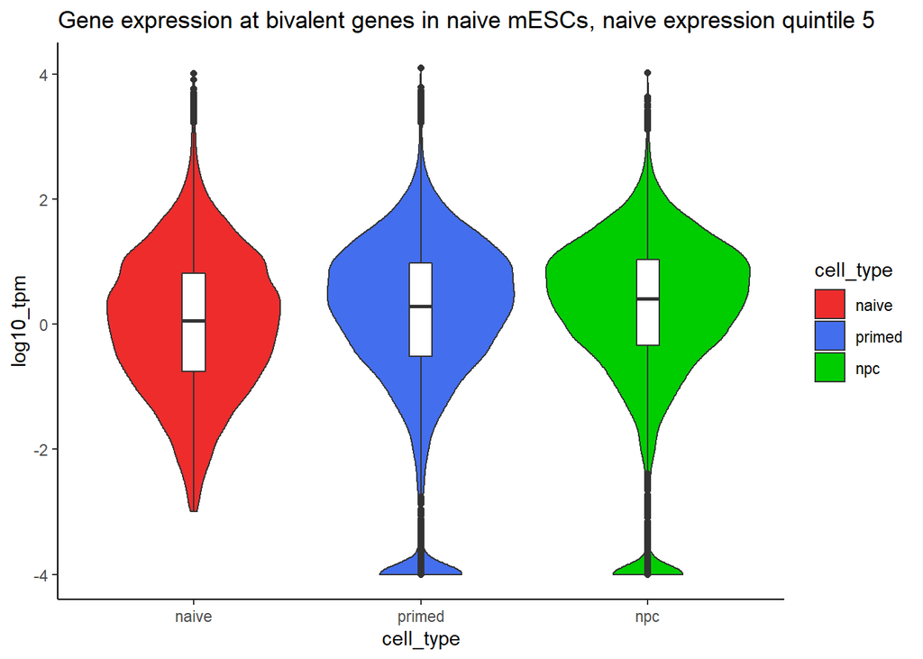

```r
gene_expression_bivalent = gene_expression %>% filter(refseq_id %in% bivalent_genes_25$naive)
violin_df = gene_expression_bivalent %>% select(refseq_id:npc) %>% mutate(across(.cols = naive:npc, .fns = ~log10(.+.0001))) %>% filter(naive>=-3) %>% gather(key = "cell_type", value = "log10_tpm", -refseq_id)
violin_df$cell_type = factor(violin_df$cell_type, levels = c('naive', 'primed', 'npc'), ordered = TRUE)

violin_plt = ggplot(data = violin_df, aes(x = cell_type, y = log10_tpm, fill = cell_type)) + geom_violin() +  stat_summary(fun=mean, geom="point", shape=23, size=2, fill = "black") + theme_classic() + geom_boxplot(fill = "white", width = 0.1) + scale_fill_manual(values = c("firebrick2", "royalblue2", "green3")) + labs(title = paste0("Gene expression at bivalent genes in naive mESCs, naive expression quintile ", i))
print(violin_plt)
```

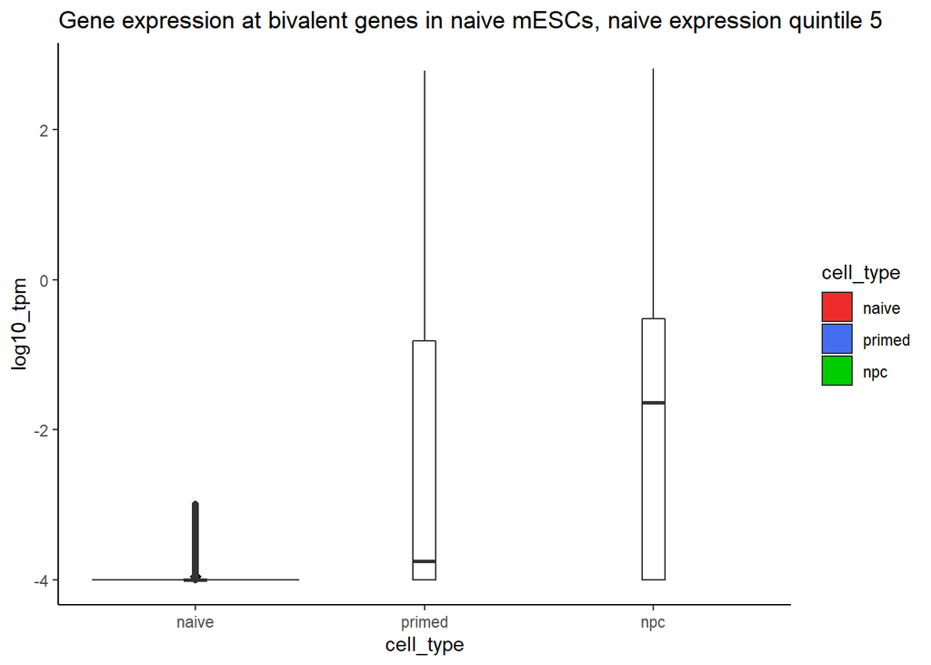

```r
violin_df = gene_expression_bivalent %>% select(refseq_id:npc) %>% mutate(across(.cols = naive:npc, .fns = ~log10(.+.0001))) %>% filter(naive< -3) %>% gather(key = "cell_type", value = "log10_tpm", -refseq_id)
violin_df$cell_type = factor(violin_df$cell_type, levels = c('naive', 'primed', 'npc'), ordered = TRUE)

violin_plt = ggplot(data = violin_df, aes(x = cell_type, y = log10_tpm, fill = cell_type)) + geom_violin() +  stat_summary(fun=mean, geom="point", shape=23, size=2, fill = "black") + theme_classic() + geom_boxplot(fill = "white", width = 0.1) + scale_fill_manual(values = c("firebrick2", "royalblue2", "green3")) + labs(title = paste0("Gene expression at bivalent genes in naive mESCs, naive expression quintile ", i))
print(violin_plt)
```

I don’t really know what to say, it looks basically the same there.

To check if the quintiles spread is real effect or just due to chance, I will do the same thing, but working off quintiles for npc instead.

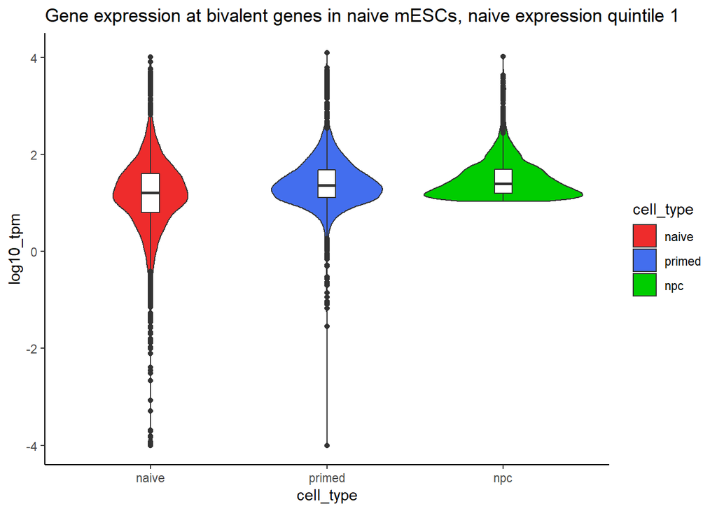

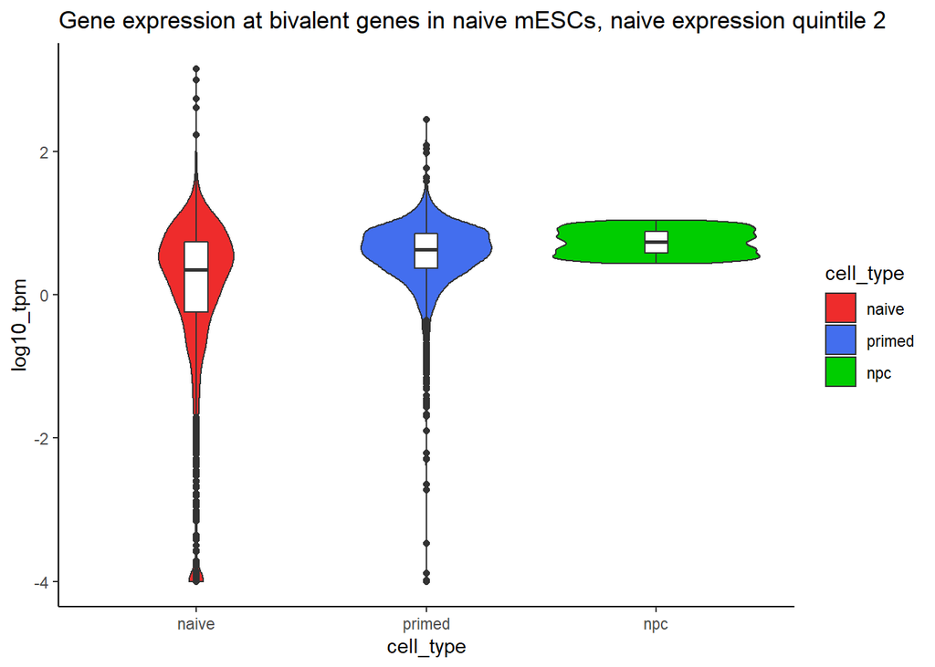

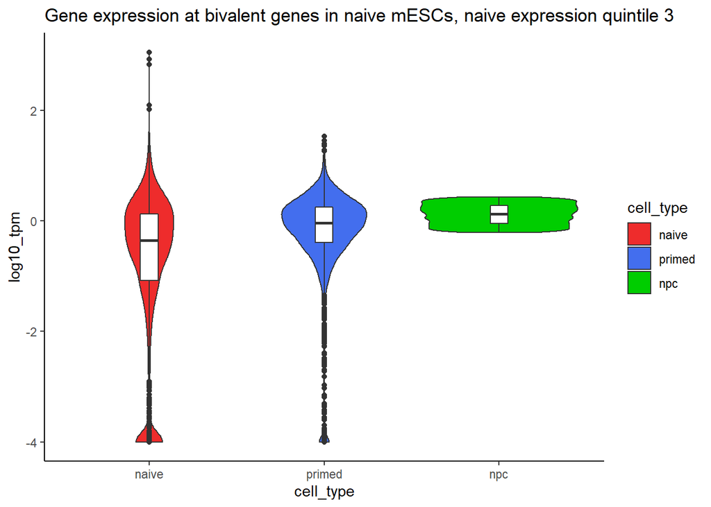

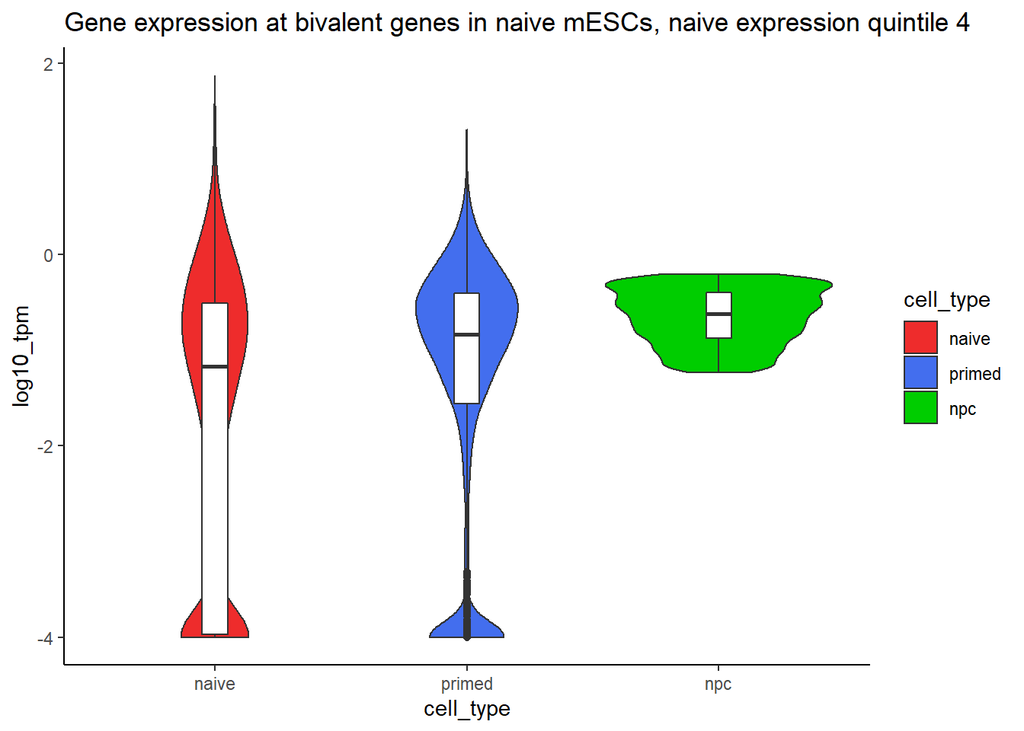

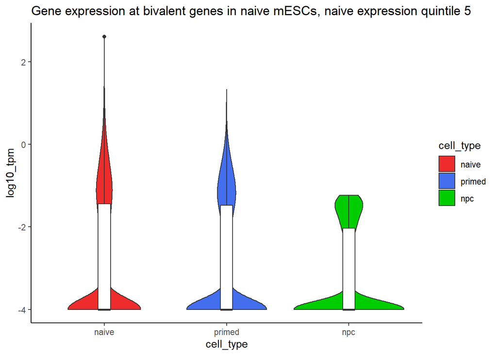

```r
for (i in 1:5)
{
  gene_expression_bivalent = gene_expression %>% filter(refseq_id %in% bivalent_genes_25$naive)
  countup = floor(length(gene_expression_bivalent$naive)/5)
  violin_df = gene_expression_bivalent %>% arrange(desc(npc)) %>%  slice((countup*(i-1)):(countup*i - 1)) %>% select(refseq_id:npc) %>% mutate(across(.cols = naive:npc, .fns = ~log10(.+.0001))) %>% gather(key = "cell_type", value = "log10_tpm", -refseq_id)
  violin_df$cell_type = factor(violin_df$cell_type, levels = c('naive', 'primed', 'npc'), ordered = TRUE)

  violin_plt = ggplot(data = violin_df, aes(x = cell_type, y = log10_tpm, fill = cell_type)) + geom_violin() +  stat_summary(fun=mean, geom="point", shape=23, size=2, fill = "black") + theme_classic() + geom_boxplot(fill = "white", width = 0.1) + scale_fill_manual(values = c("firebrick2", "royalblue2", "green3")) + labs(title = paste0("Gene expression at bivalent genes in naive mESCs, naive expression quintile ", i))
  print(violin_plt)
}
```

```r
rm(gene_expression_bivalent, countup, violin_df, violin_plt)
```

Okay it looks very similar, I will take that to mean that it’s just chance.

## Metaprofiles by gene expression

The other obvious thing is to look at upregulated genes, downregulated genes, and insignificantly changed genes to look at bivalency metaprofiles there.

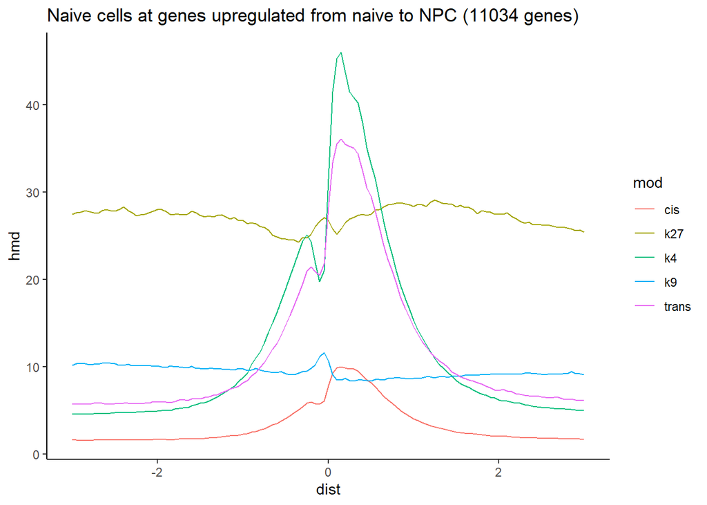

```r
metagene_plot(metagene(naive, tss_range, upregulated_genes$naive_npc), title = paste0("Naive cells at genes upregulated from naive to NPC (", length(upregulated_genes$naive_npc), " genes)"))
```

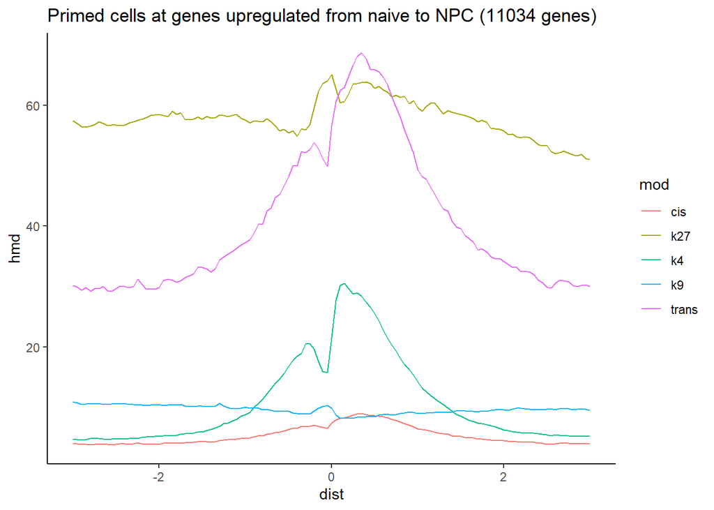

```r
metagene_plot(metagene(primed, tss_range, upregulated_genes$naive_npc), title = paste0("Primed cells at genes upregulated from naive to NPC (", length(upregulated_genes$naive_npc), " genes)"))
```

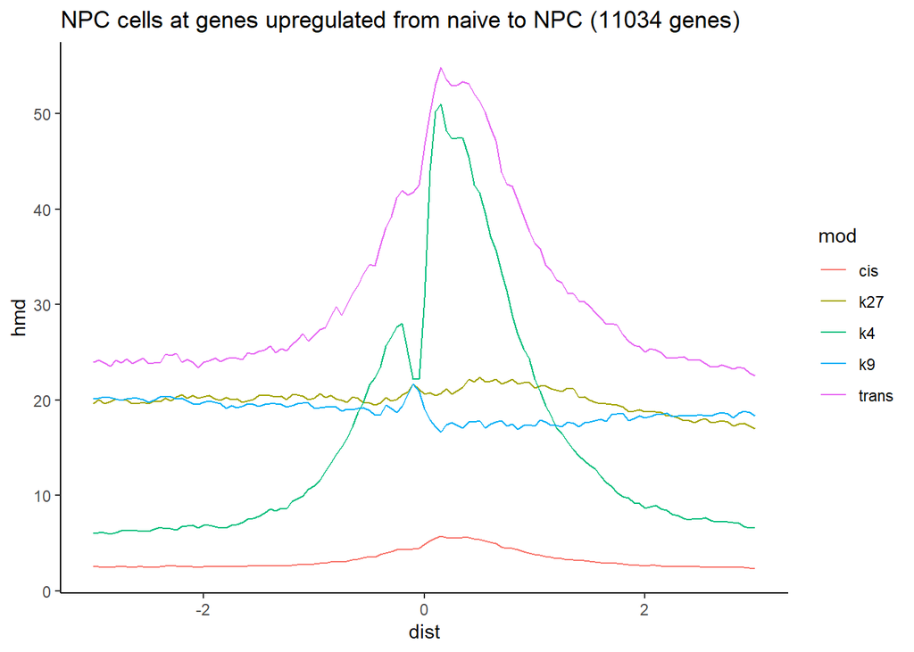

```r
metagene_plot(metagene(npc, tss_range, upregulated_genes$naive_npc), title = paste0("NPC cells at genes upregulated from naive to NPC (", length(upregulated_genes$naive_npc), " genes)"))
```

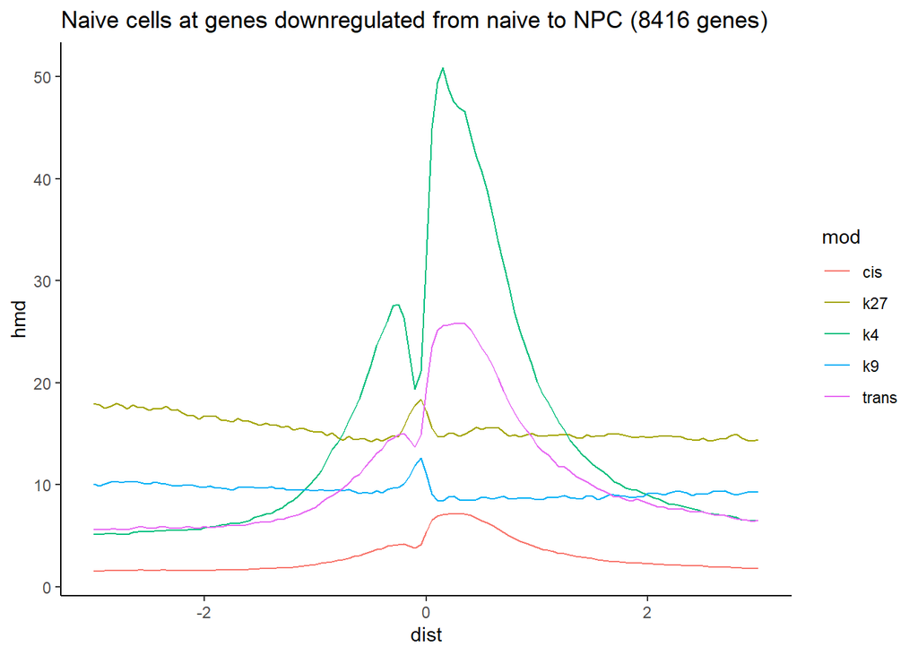

```r
metagene_plot(metagene(naive, tss_range, downregulated_genes$naive_npc), title = paste0("Naive cells at genes downregulated from naive to NPC (", length(downregulated_genes$naive_npc), " genes)"))
```

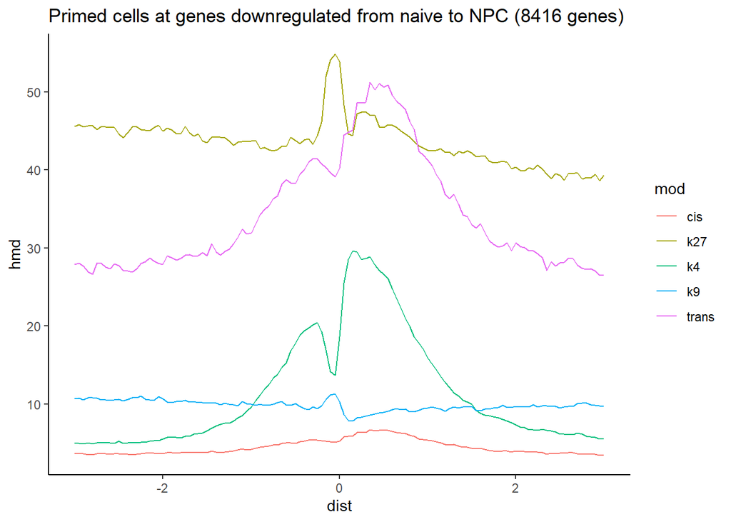

```r
metagene_plot(metagene(primed, tss_range, downregulated_genes$naive_npc), title = paste0("Primed cells at genes downregulated from naive to NPC (", length(downregulated_genes$naive_npc), " genes)"))
```

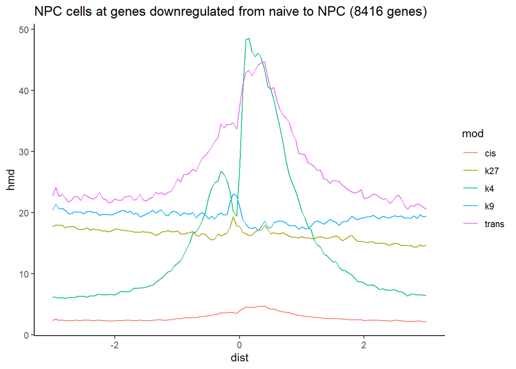

```r
metagene_plot(metagene(npc, tss_range, downregulated_genes$naive_npc), title = paste0("NPC cells at genes downregulated from naive to NPC (", length(downregulated_genes$naive_npc), " genes)"))
```

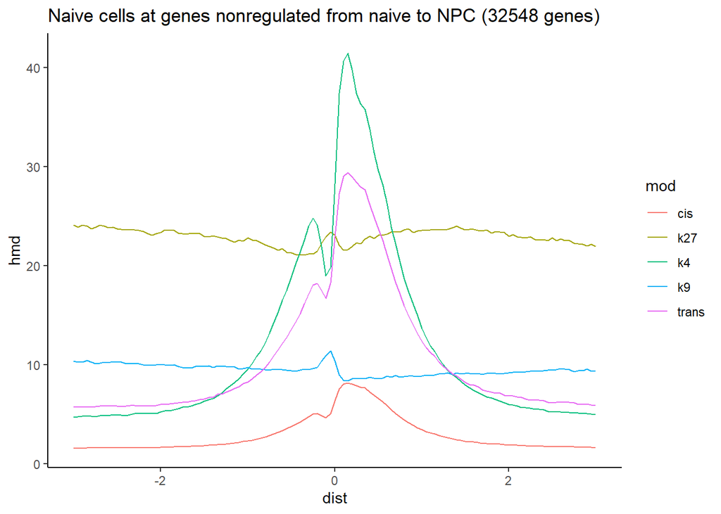

```r
metagene_plot(metagene(naive, tss_range, nonregulated_genes$naive_npc), title = paste0("Naive cells at genes nonregulated from naive to NPC (", length(nonregulated_genes$naive_npc), " genes)"))
```

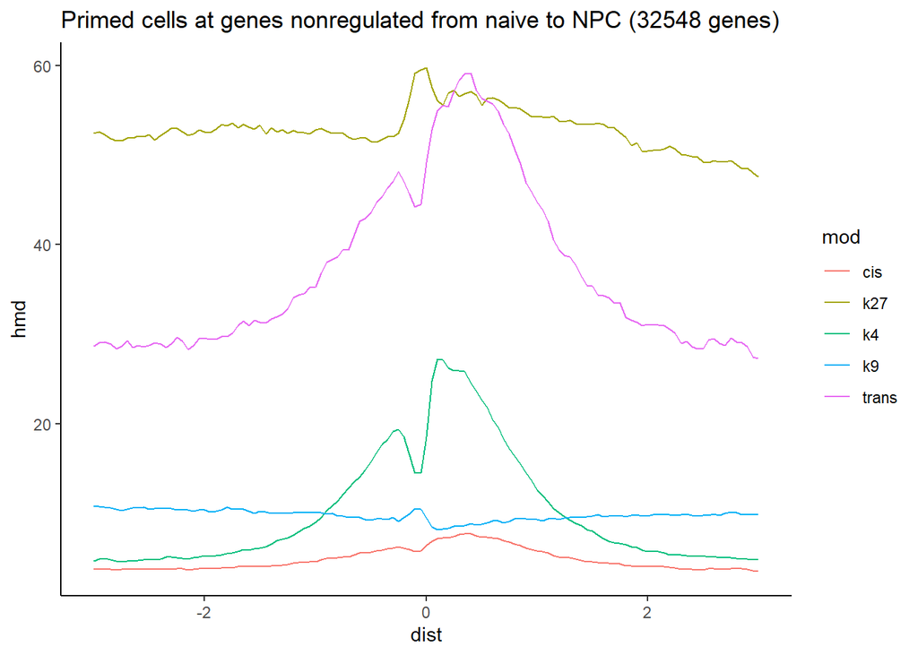

```r
metagene_plot(metagene(primed, tss_range, nonregulated_genes$naive_npc), title = paste0("Primed cells at genes nonregulated from naive to NPC (", length(nonregulated_genes$naive_npc), " genes)"))
```

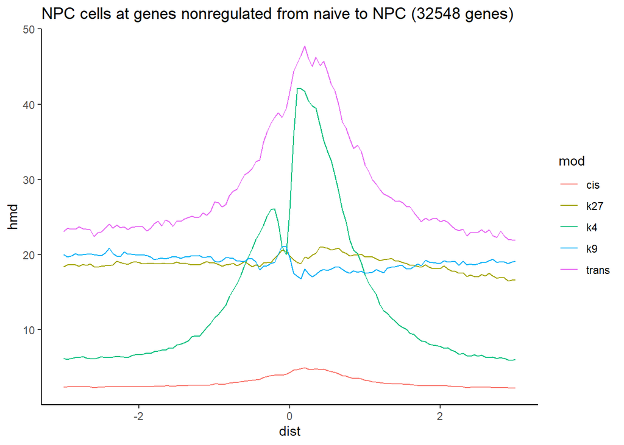

```r
metagene_plot(metagene(npc, tss_range, nonregulated_genes$naive_npc), title = paste0("NPC cells at genes nonregulated from naive to NPC (", length(nonregulated_genes$naive_npc), " genes)"))
```

Minor differences in magnitude aside, there is basically no difference between the bivalency profiles of upregulated and downregulated genes.

# Gene ontology and bivalency classes

We can now move on to running gene ontology on our different bivalency classes. We will run these by Ensembl gene IDs. First order of business is to set up our analysis by preparing the data.

```r
if (!file.exists("go_struct.RData")){
  ensembl_dominance = list()
  ensembl_dominance$k27 = (refseq_ensembl_external_go %>% filter(refseq_id %in% naive_dominance$k27) %>% filter(ensembl_gene_id %in% ensembl_with_go))$ensembl_gene_id %>% unique
  ensembl_dominance$k4 = (refseq_ensembl_external_go %>% filter(refseq_id %in% naive_dominance$k4) %>% filter(ensembl_gene_id %in% ensembl_with_go))$ensembl_gene_id %>% unique
  ensembl_dominance$mid = (refseq_ensembl_external_go %>% filter(refseq_id %in% naive_dominance$mid) %>% filter(ensembl_gene_id %in% ensembl_with_go))$ensembl_gene_id %>% unique

  gene_2_go = unstack((refseq_ensembl_external_go %>% filter(ensembl_gene_id %in% ensembl_with_go))[,c(4,2)])

  genelists_ontology = list()
  genelists_ontology$k27 = factor(as.integer(ensembl_with_go %in% ensembl_dominance$k27))
  names(genelists_ontology$k27) = ensembl_with_go
  genelists_ontology$k4 = factor(as.integer(ensembl_with_go %in% ensembl_dominance$k4))
  names(genelists_ontology$k4) = ensembl_with_go
  genelists_ontology$mid = factor(as.integer(ensembl_with_go %in% ensembl_dominance$mid))
  names(genelists_ontology$mid) = ensembl_with_go

  godata = list()
  godata$k27 = new('topGOdata', ontology = 'BP', allGenes = genelists_ontology$k27, annot = annFUN.gene2GO, gene2GO = gene_2_go)
  godata$k4 = new('topGOdata', ontology = 'BP', allGenes = genelists_ontology$k4, annot = annFUN.gene2GO, gene2GO = gene_2_go)
  godata$mid = new('topGOdata', ontology = 'BP', allGenes = genelists_ontology$mid, annot = annFUN.gene2GO, gene2GO = gene_2_go)
  save.image("go_struct.RData")
} else {
  load("go_struct.RData")
}
```

Having set that up, we will now define a function so that we can run gene ontology analyses and test for significance more efficiently.

```r
testGO = function(GOdata, algo = "classic"){
  fisher_result = runTest(GOdata, algorithm = algo, statistic = "fisher")
  allGO = usedGO(GOdata)
  all_res = GenTable(GOdata, Fisher = fisher_result, orderBy = 'Fisher', topNodes = length(allGO))
  p.adj=round(p.adjust(all_res$Fisher,method="BH"),digits = 4)
  p.adj[is.na(p.adj)] = 0
  all_res_final=cbind(all_res,p.adj)
  all_res_final=all_res_final[order(all_res_final$p.adj),]
  return(all_res_final)
}
```

We valswill now conduct GO analysis on the datasets described above.

```r
go_classic_tables = list()
go_classic_tables$k27 = testGO(godata$k27)
```

```
##
##           -- Classic Algorithm --
##
##       the algorithm is scoring 7588 nontrivial nodes
##       parameters:
##           test statistic: fisher
```

```r
go_classic_tables$k4 = testGO(godata$k4)
```

```
##
##           -- Classic Algorithm --
##
##       the algorithm is scoring 9892 nontrivial nodes
##       parameters:
##           test statistic: fisher
```

```r
go_classic_tables$mid = testGO(godata$mid)
```

```
##
##           -- Classic Algorithm --
##
##       the algorithm is scoring 11715 nontrivial nodes
##       parameters:
##           test statistic: fisher
```

I don’t know what to do here – I guess pull out some of the terms that we looked at before?

```r
go_term_pvals = data.frame(GO.ID = c("GO:0032502", "GO:0009790", "GO:0019827", "GO:0030182", "GO:0008152", "GO:0002376"))
go_term_pvals = go_term_pvals %>% inner_join(go_classic_tables$k27, by = "GO.ID") %>% select(GO.ID, Term, k27 = p.adj)
go_term_pvals = go_term_pvals %>% inner_join(go_classic_tables$k4, by = "GO.ID") %>% select(GO.ID, Term = Term.x, k27, k4 = p.adj)
go_term_pvals = go_term_pvals %>% inner_join(go_classic_tables$mid, by = "GO.ID") %>% select(GO.ID, Term = Term.x, k27, k4, mid = p.adj)

print(go_term_pvals)
```

```
##        GO.ID                             Term    k27     k4    mid
## 1 GO:0032502            developmental process 0.0000 1.0000 0.0000
## 2 GO:0009790               embryo development 0.0000 0.1520 0.0000
## 3 GO:0019827 stem cell population maintenance 0.0507 0.0019 0.5518
## 4 GO:0030182           neuron differentiation 0.0000 1.0000 0.0000
## 5 GO:0008152                metabolic process 1.0000 0.0000 0.0000
## 6 GO:0002376            immune system process 0.0462 1.0000 1.0000
```

# Reverse feature search

We haven’t found any good features that are uniquely associated with bivalency, so I guess we’re just going to go the opposite direction: look for genes that obey the classic paradigm of bivalency, then identify the features to which they belong. We will identify genes that are >25% bivalent in naive with < 10% bivalent in NPCs that are differentially expressed between the two.

```r
bivalent_loss = setdiff(bivalent_genes_25$naive, bivalent_genes_10$npc)
bivalent_loss_de = (sleuth_table_gene$naive_npc %>% filter(qval <= 0.05) %>% filter(refseq_id %in% bivalent_loss))$refseq_id
```

There are only 432 Refseq IDs associated with classic features of bivalency. That’s kind of sad. I guess we should do metagene profiles.

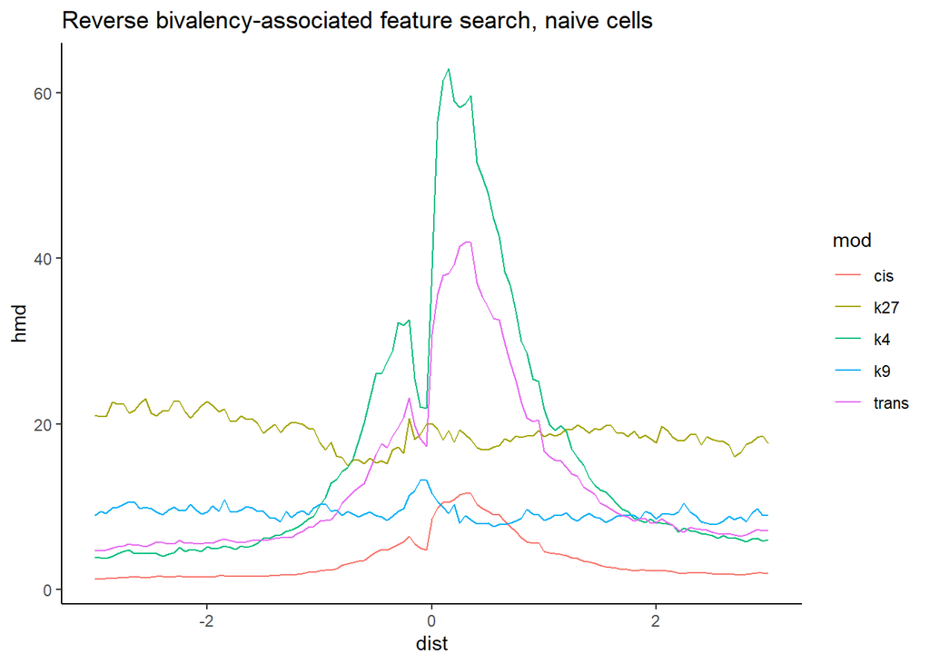

```r
metagene_plot(metagene(naive, tss_range, bivalent_loss_de), title = "Reverse bivalency-associated feature search, naive cells")
```

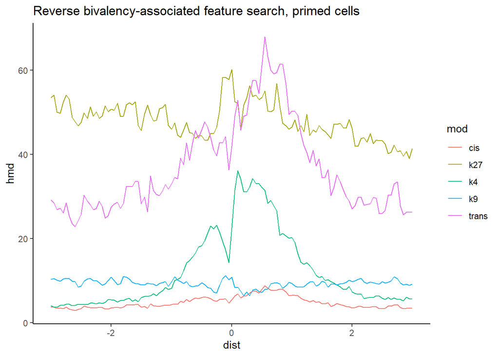

```r
metagene_plot(metagene(primed, tss_range, bivalent_loss_de), title = "Reverse bivalency-associated feature search, primed cells")
```

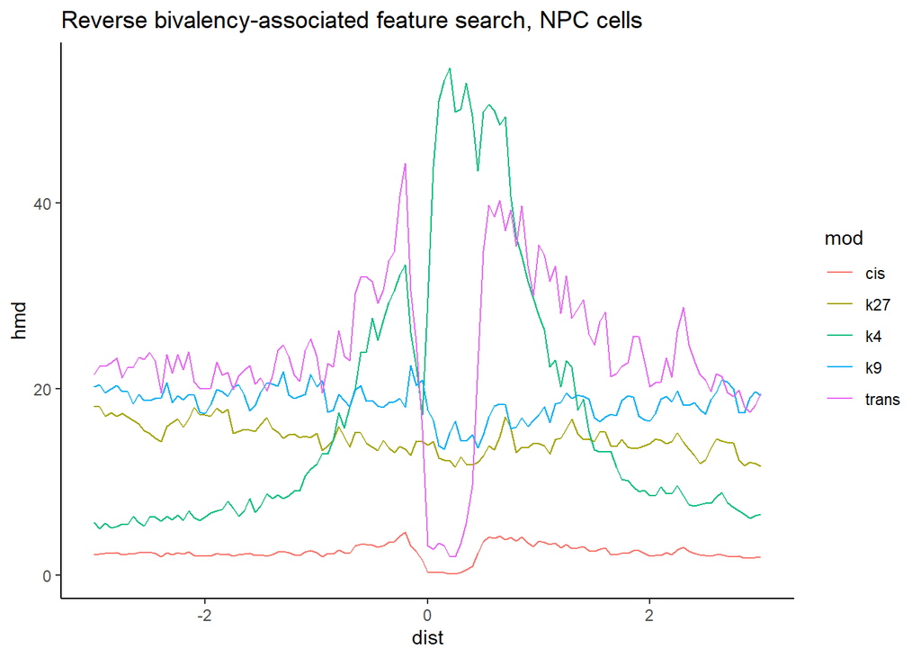

```r
metagene_plot(metagene(npc, tss_range, bivalent_loss_de), title = "Reverse bivalency-associated feature search, NPC cells")
```

That looks like shit. Let’s separate by upregulated and downregulated genes.

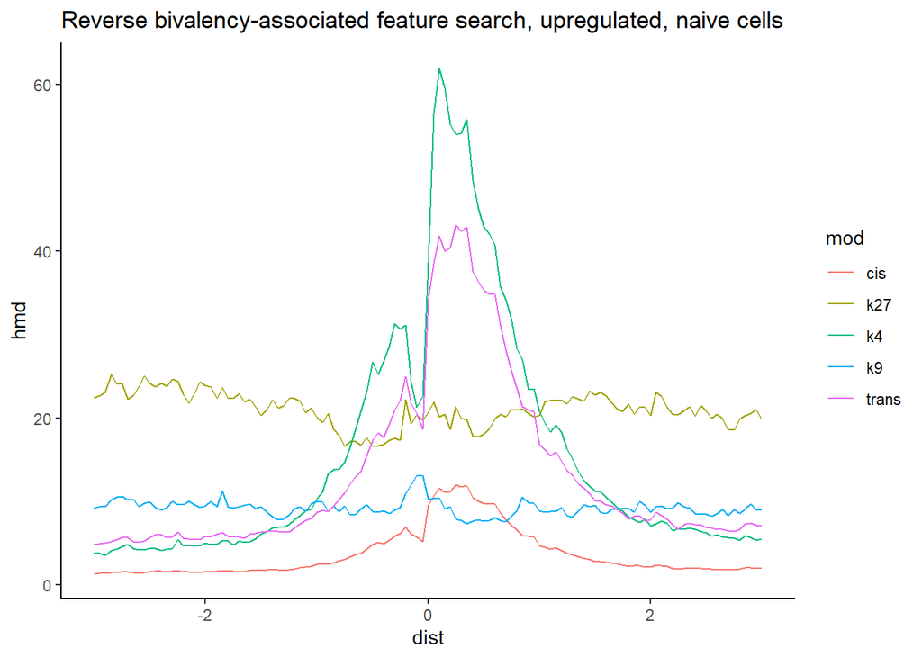

```r
bivalent_loss_de_up = bivalent_loss_de[bivalent_loss_de %in% upregulated_genes$naive_npc]
bivalent_loss_de_down = bivalent_loss_de[bivalent_loss_de %in% downregulated_genes$naive_npc]

metagene_plot(metagene(naive, tss_range, bivalent_loss_de_up), title = "Reverse bivalency-associated feature search, upregulated, naive cells")
```

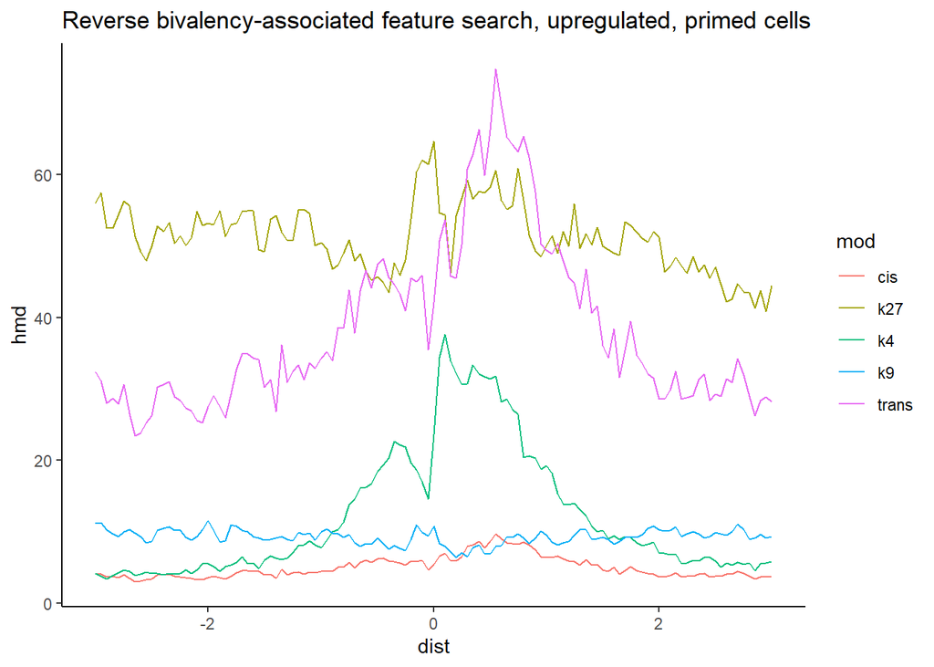

```r
metagene_plot(metagene(primed, tss_range, bivalent_loss_de_up), title = "Reverse bivalency-associated feature search, upregulated, primed cells")
```

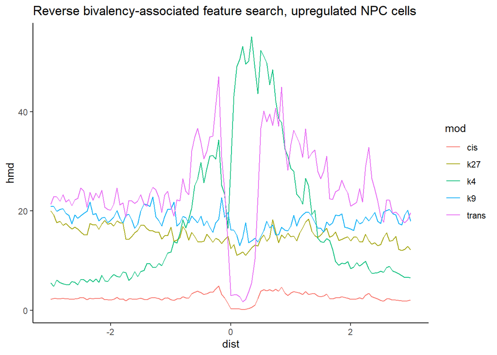

```r
metagene_plot(metagene(npc, tss_range, bivalent_loss_de_up), title = "Reverse bivalency-associated feature search, upregulated NPC cells")
```

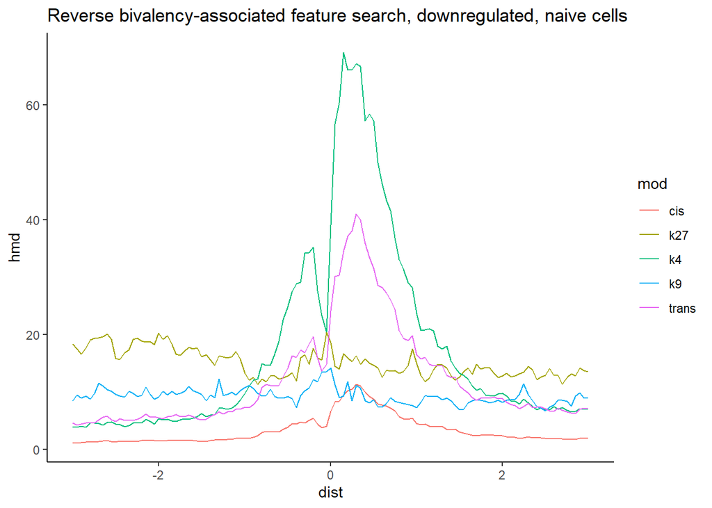

```r
metagene_plot(metagene(naive, tss_range, bivalent_loss_de_down), title = "Reverse bivalency-associated feature search, downregulated, naive cells")
```

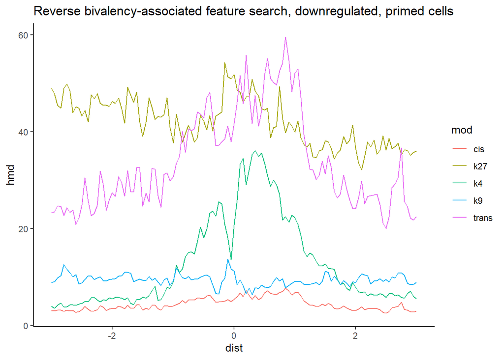

```r
metagene_plot(metagene(primed, tss_range, bivalent_loss_de_down), title = "Reverse bivalency-associated feature search, downregulated, primed cells")
```

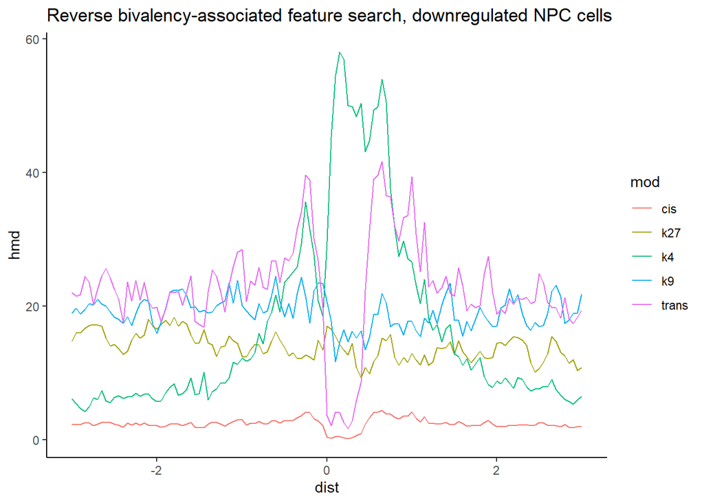

```r
metagene_plot(metagene(npc, tss_range, bivalent_loss_de_down), title = "Reverse bivalency-associated feature search, downregulated NPC cells")
```

It continues to look like shit. Let’s look at the gene ontology classes here.

```r
bivalent_loss_de_ensembl = (refseq_ensembl_external_go %>% filter(refseq_id %in% bivalent_loss_de) %>% filter(ensembl_gene_id %in% ensembl_with_go))$ensembl_gene_id %>% unique

genelists_ontology$biv_loss_de = factor(as.integer(ensembl_with_go %in% bivalent_loss_de_ensembl))
names(genelists_ontology$biv_loss_de) = ensembl_with_go

godata$biv_loss_de = new('topGOdata', ontology = 'BP', allGenes = genelists_ontology$biv_loss_de, annot = annFUN.gene2GO, gene2GO = gene_2_go)
```

```
##
## Building most specific GOs .....
```

```
##  ( 12504 GO terms found. )
```

```
##
## Build GO DAG topology ..........
```

```
##  ( 16135 GO terms and 38206 relations. )
```

```
##
## Annotating nodes ...............
```

```
##  ( 19957 genes annotated to the GO terms. )
```

```r
go_classic_tables$biv_loss_de = testGO(godata$biv_loss_de)
```

```
##
##           -- Classic Algorithm --
##
##       the algorithm is scoring 4648 nontrivial nodes
##       parameters:
##           test statistic: fisher
```

```r
go_term_pvals %>% inner_join(go_classic_tables$biv_loss_de, by = "GO.ID") %>% select(GO.ID, Term = Term.x, p.adj)
```

```
##        GO.ID                             Term  p.adj
## 1 GO:0032502            developmental process 1.0000
## 2 GO:0009790               embryo development 0.6172
## 3 GO:0019827 stem cell population maintenance 1.0000
## 4 GO:0030182           neuron differentiation 1.0000
## 5 GO:0008152                metabolic process 0.0000
## 6 GO:0002376            immune system process 1.0000
```

It’s enriched overwhelmingly for metabolic processes. Now we will do the same thing, but up and down.

```r
bivalent_loss_de_up_ensembl = (refseq_ensembl_external_go %>% filter(refseq_id %in% bivalent_loss_de_up) %>% filter(ensembl_gene_id %in% ensembl_with_go))$ensembl_gene_id %>% unique

genelists_ontology$biv_loss_de_up = factor(as.integer(ensembl_with_go %in% bivalent_loss_de_up_ensembl))
names(genelists_ontology$biv_loss_de_up) = ensembl_with_go

godata$biv_loss_de_up = new('topGOdata', ontology = 'BP', allGenes = genelists_ontology$biv_loss_de_up, annot = annFUN.gene2GO, gene2GO = gene_2_go)
```

```
##
## Building most specific GOs .....
```

```
##  ( 12504 GO terms found. )
```

```
##
## Build GO DAG topology ..........
```

```
##  ( 16135 GO terms and 38206 relations. )
```

```
##
## Annotating nodes ...............
```

```
##  ( 19957 genes annotated to the GO terms. )
```

```r
go_classic_tables$biv_loss_de_up = testGO(godata$biv_loss_de_up)
```

```
##
##           -- Classic Algorithm --
##
##       the algorithm is scoring 3858 nontrivial nodes
##       parameters:
##           test statistic: fisher
```

```r
go_term_pvals %>% inner_join(go_classic_tables$biv_loss_de_up, by = "GO.ID") %>% select(GO.ID, Term = Term.x, p.adj)
```

```
##        GO.ID                             Term  p.adj
## 1 GO:0032502            developmental process 0.8705
## 2 GO:0009790               embryo development 0.6150
## 3 GO:0019827 stem cell population maintenance 0.6912
## 4 GO:0030182           neuron differentiation 1.0000
## 5 GO:0008152                metabolic process 0.0014
## 6 GO:0002376            immune system process 1.0000
```

```r
bivalent_loss_de_down_ensembl = (refseq_ensembl_external_go %>% filter(refseq_id %in% bivalent_loss_de_down) %>% filter(ensembl_gene_id %in% ensembl_with_go))$ensembl_gene_id %>% unique

genelists_ontology$biv_loss_de_down = factor(as.integer(ensembl_with_go %in% bivalent_loss_de_down_ensembl))
names(genelists_ontology$biv_loss_de_down) = ensembl_with_go

godata$biv_loss_de_down = new('topGOdata', ontology = 'BP', allGenes = genelists_ontology$biv_loss_de_down, annot = annFUN.gene2GO, gene2GO = gene_2_go)
```

```
##
## Building most specific GOs .....
```

```
##  ( 12504 GO terms found. )
```

```
##
## Build GO DAG topology ..........
```

```
##  ( 16135 GO terms and 38206 relations. )
```

```
##
## Annotating nodes ...............
```

```
##  ( 19957 genes annotated to the GO terms. )
```

```r
go_classic_tables$biv_loss_de_down = testGO(godata$biv_loss_de_down)
```

```
##
##           -- Classic Algorithm --
##
##       the algorithm is scoring 2793 nontrivial nodes
##       parameters:
##           test statistic: fisher
```

```r
go_term_pvals %>% inner_join(go_classic_tables$biv_loss_de_down, by = "GO.ID") %>% select(GO.ID, Term = Term.x, p.adj)
```

```
##        GO.ID                             Term  p.adj
## 1 GO:0032502            developmental process 1.0000
## 2 GO:0009790               embryo development 1.0000
## 3 GO:0019827 stem cell population maintenance 1.0000
## 4 GO:0030182           neuron differentiation 1.0000
## 5 GO:0008152                metabolic process 0.0056
## 6 GO:0002376            immune system process 1.0000
```

Okay, in both terms, the only significant top-level term is metabolic processes.

# Classification of genes

This is essentially asking the final question about whether bivalency is actually an example of the “histone code.” We will create a classification variable to identify whether a gene is developmentally regulated.

First we will look at naive to npc, then look at primed to npc.

## Naive to NPC

```r
hmd_diffexp_naive_npc = hmds$naive %>% inner_join(sleuth_table_gene$naive_npc, by = c("Gene" = "refseq_id")) %>% select(Gene:k27, trans, qval) %>% mutate(diffexp = ifelse(qval <= 0.05, 1, 0)) %>% mutate(diffexp = as.factor(diffexp)) %>% mutate(logk4 = log(k4+1), logk27 = log(k27+1), logtrans = log(trans+1), logk9 = log(k9+1)) %>% select(diffexp, k4, logk4, k27, logk27, k9, logk9, trans, logtrans)

naive_npc_BICs = numeric()

# Trivial Model
naive_npc_BICs["trivial"] = BIC(glm(diffexp ~ 1, data = hmd_diffexp_naive_npc, family = binomial))

# K4 only
naive_npc_BICs["k4"] = BIC(glm(diffexp ~ k4, data = hmd_diffexp_naive_npc, family = binomial))

# K27 only
naive_npc_BICs["k27"] = BIC(glm(diffexp ~ k27, data = hmd_diffexp_naive_npc, family = binomial))

# K9 only
naive_npc_BICs["k9"] = BIC(glm(diffexp ~ k9, data = hmd_diffexp_naive_npc, family = binomial))

# trans only
naive_npc_BICs["trans"] = BIC(glm(diffexp ~ trans, data = hmd_diffexp_naive_npc, family = binomial))

# K4 + K27
naive_npc_BICs["k4_k27"] = BIC(glm(diffexp ~ k4 + k27, data = hmd_diffexp_naive_npc, family = binomial))

# K4 + K27 + trans
naive_npc_BICs["k4_k27_trans"] = BIC(glm(diffexp ~ k4 + k27 + trans, data = hmd_diffexp_naive_npc, family = binomial))

# K4 + K27 + log of each
naive_npc_BICs["k4_k27_logs"] = BIC(glm(diffexp ~ k4 + k27 + logk4 + logk27, data = hmd_diffexp_naive_npc, family = binomial))

# K4 + K27 + log of each + bivalency
naive_npc_BICs["k4_k27_trans_logs"] = BIC(glm(diffexp ~ k4 + k27 + trans + logk4 + logk27 + logtrans, data = hmd_diffexp_naive_npc, family = binomial))

print(naive_npc_BICs[order(naive_npc_BICs)])
```

```
##       k4_k27_logs k4_k27_trans_logs            k4_k27      k4_k27_trans
##          31681.10          31699.31          31755.64          31765.44
##                k4             trans           trivial               k27
##          31799.66          32049.08          32182.03          32190.74
##                k9
##          32191.98
```

On the whole, we find that the model with K4 and K27 with logs of both minimizes BIC by 18.21, which is massive.

Full summary of top two models:

```r
glm_k4_k27_logs_naive_npc = glm(diffexp ~ k4 + k27 + logk4 + logk27, data = hmd_diffexp_naive_npc, family = binomial)

glm_k4_k27_logs_naive_npc_trans = glm(diffexp ~ k4 + k27 + logk4 + logk27 + trans + logtrans, data = hmd_diffexp_naive_npc, family = binomial)

# K4, K27, log K4, log K27
summary(glm_k4_k27_logs_naive_npc)
```

```
##
## Call:
## glm(formula = diffexp ~ k4 + k27 + logk4 + logk27, family = binomial,
##     data = hmd_diffexp_naive_npc)
##
## Deviance Residuals:
##     Min       1Q   Median       3Q      Max
## -2.2189  -1.1960   0.9187   1.1283   1.6012
##
## Coefficients:
##              Estimate Std. Error z value Pr(>|z|)
## (Intercept) -0.332649   0.102540  -3.244  0.00118 **
## k4           0.006998   0.001414   4.950 7.43e-07 ***
## k27          0.016506   0.001491  11.069  < 2e-16 ***
## logk4        0.178120   0.036182   4.923 8.53e-07 ***
## logk27      -0.313040   0.035657  -8.779  < 2e-16 ***
## ---
## Signif. codes:  0 '***' 0.001 '**' 0.01 '*' 0.05 '.' 0.1 ' ' 1
##
## (Dispersion parameter for binomial family taken to be 1)
##
##     Null deviance: 32172  on 23211  degrees of freedom
## Residual deviance: 31631  on 23207  degrees of freedom
## AIC: 31641
##
## Number of Fisher Scoring iterations: 4
```

```r
# K4, K27, log K4, log K27, trans
summary(glm_k4_k27_logs_naive_npc_trans)
```

```
##
## Call:
## glm(formula = diffexp ~ k4 + k27 + logk4 + logk27 + trans + logtrans,
##     family = binomial, data = hmd_diffexp_naive_npc)
##
## Deviance Residuals:
##     Min       1Q   Median       3Q      Max
## -2.1776  -1.1950   0.9177   1.1289   1.6326
##
## Coefficients:
##              Estimate Std. Error z value Pr(>|z|)
## (Intercept) -0.378005   0.110636  -3.417 0.000634 ***
## k4           0.007823   0.001540   5.079 3.79e-07 ***
## k27          0.016856   0.001571  10.733  < 2e-16 ***
## logk4        0.135992   0.051146   2.659 0.007840 **
## logk27      -0.325322   0.037026  -8.786  < 2e-16 ***
## trans       -0.002213   0.001709  -1.295 0.195343
## logtrans     0.078714   0.058657   1.342 0.179618
## ---
## Signif. codes:  0 '***' 0.001 '**' 0.01 '*' 0.05 '.' 0.1 ' ' 1
##
## (Dispersion parameter for binomial family taken to be 1)
##
##     Null deviance: 32172  on 23211  degrees of freedom
## Residual deviance: 31629  on 23205  degrees of freedom
## AIC: 31643
##
## Number of Fisher Scoring iterations: 4
```

Of course, this should be done better. We will use training and testing data.

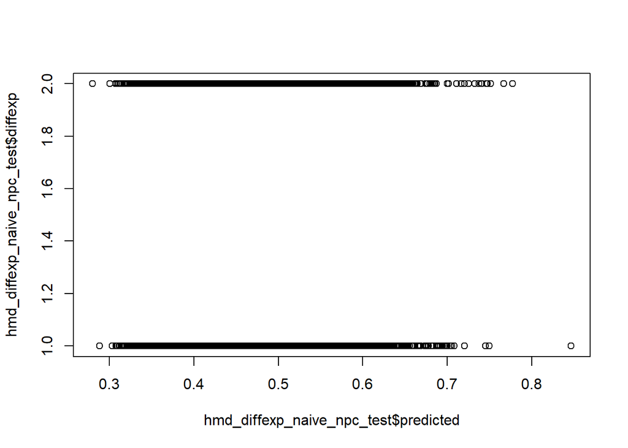

```r
set.seed(1209)

sample = sample.int(n = nrow(hmd_diffexp_naive_npc), size = floor(.7*nrow(hmd_diffexp_naive_npc)), replace = F)

hmd_diffexp_naive_npc_train = hmd_diffexp_naive_npc[sample,]
hmd_diffexp_naive_npc_test = hmd_diffexp_naive_npc[-sample,]

glm_k4_k27_logs_naive_npc_train = glm(diffexp ~ k4 + k27 + logk4 + logk27, data = hmd_diffexp_naive_npc_train, family = binomial)
glm_k4_k27_logs_naive_npc_trans_train = glm(diffexp ~ k4 + k27 + logk4 + logk27 + trans + logtrans, data = hmd_diffexp_naive_npc_train, family = binomial)
glm_k4_k27_logs_naive_npc_k9_train = glm(diffexp ~ k4 + k27 + logk4 + logk27 + k9, data = hmd_diffexp_naive_npc_train, family = binomial)

hmd_diffexp_naive_npc_test$predicted = predict(glm_k4_k27_logs_naive_npc_train, newdata = hmd_diffexp_naive_npc_test, type = "response")
hmd_diffexp_naive_npc_test$predicted_trans = predict(glm_k4_k27_logs_naive_npc_trans_train, newdata = hmd_diffexp_naive_npc_test, type = "response")
hmd_diffexp_naive_npc_test$predicted_k9 = predict(glm_k4_k27_logs_naive_npc_k9_train, newdata = hmd_diffexp_naive_npc_test, type = "response")

plot(x = hmd_diffexp_naive_npc_test$predicted, y = hmd_diffexp_naive_npc_test$diffexp)
```

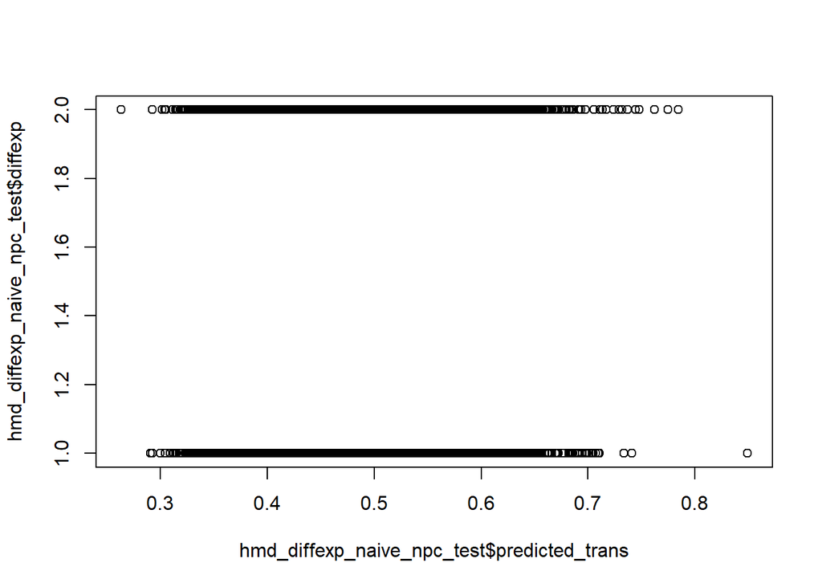

```r
plot(x = hmd_diffexp_naive_npc_test$predicted_trans, y = hmd_diffexp_naive_npc_test$diffexp)
```

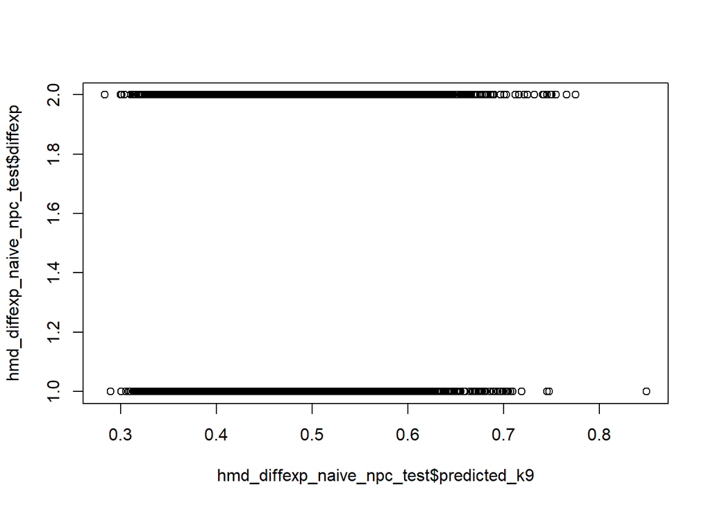

```r
plot(x = hmd_diffexp_naive_npc_test$predicted_k9, y = hmd_diffexp_naive_npc_test$diffexp)
```

```r
hmd_diffexp_naive_npc_test = hmd_diffexp_naive_npc_test %>% mutate(predicted_dir = ifelse(predicted>0.5, 1, 0), predicted_dir_trans = ifelse(predicted_trans>0.5, 1, 0), predicted_dir_k9 = ifelse(predicted_k9>0.5, 1, 0))

mean(1==hmd_diffexp_naive_npc_test$diffexp)
```

```
## [1] 0.5133544
```

```r
mean(hmd_diffexp_naive_npc_test$predicted_dir==hmd_diffexp_naive_npc_test$diffexp)
```

```
## [1] 0.5628949
```

```r
mean(hmd_diffexp_naive_npc_test$predicted_dir_trans==hmd_diffexp_naive_npc_test$diffexp)
```

```
## [1] 0.5639001
```

```r
mean(hmd_diffexp_naive_npc_test$predicted_dir_k9==hmd_diffexp_naive_npc_test$diffexp)
```

```
## [1] 0.5640437
```

By the trivial model where we assume everything is differentially expressed, we find that we have an accuracy rate of 51.3%. By adding in a GLM for K4, K27, log K4, and log K27, we increase accuracy rate to 56.3%. By added in trans bivalency (and log therein) to the GLM on top of that, we only increase to accuracy rate to 56.4%, and to an even lesser degree than if we instead added in K9.

## Primed to NPC

```r
hmd_diffexp_primed_npc = hmds$primed %>% inner_join(sleuth_table_gene$primed_npc, by = c("Gene" = "refseq_id")) %>% select(Gene:k27, trans, qval) %>% mutate(diffexp = ifelse(qval <= 0.05, 1, 0)) %>% mutate(diffexp = as.factor(diffexp)) %>% mutate(logk4 = log(k4+1), logk27 = log(k27+1), logtrans = log(trans+1)) %>% select(diffexp, k4, logk4, k27, logk27, k9, trans, logtrans)

primed_npc_BICs = numeric()

# Trivial Model
primed_npc_BICs["trivial"] = BIC(glm(diffexp ~ 1, data = hmd_diffexp_primed_npc, family = binomial))

# K4 only
primed_npc_BICs["k4"] = BIC(glm(diffexp ~ k4, data = hmd_diffexp_primed_npc, family = binomial))

# K27 only
primed_npc_BICs["k27"] = BIC(glm(diffexp ~ k27, data = hmd_diffexp_primed_npc, family = binomial))

# K9 only
primed_npc_BICs["k9"] = BIC(glm(diffexp ~ k9, data = hmd_diffexp_primed_npc, family = binomial))

# trans only
primed_npc_BICs["trans"] = BIC(glm(diffexp ~ trans, data = hmd_diffexp_primed_npc, family = binomial))

# K4 + K27
primed_npc_BICs["k4_k27"] = BIC(glm(diffexp ~ k4 + k27, data = hmd_diffexp_primed_npc, family = binomial))

# K4 + K27 + trans
primed_npc_BICs["k4_k27_trans"] = BIC(glm(diffexp ~ k4 + k27 + trans, data = hmd_diffexp_primed_npc, family = binomial))

# K4 + K27 + log of each
primed_npc_BICs["k4_k27_logs"] = BIC(glm(diffexp ~ k4 + k27 + logk4 + logk27, data = hmd_diffexp_primed_npc, family = binomial))

# K4 + K27 + log of each + bivalency
primed_npc_BICs["k4_k27_trans_logs"] = BIC(glm(diffexp ~ k4 + k27 + trans + logk4 + logk27 + logtrans, data = hmd_diffexp_primed_npc, family = binomial))

print(primed_npc_BICs[order(primed_npc_BICs)])
```

```
##       k4_k27_logs k4_k27_trans_logs            k4_k27      k4_k27_trans
##          28690.06          28696.84          28743.02          28749.07
##                k4               k27           trivial             trans
##          28812.13          29019.73          29060.79          29061.34
##                k9
##          29070.02
```

Full summary of top two models:

```r
glm_k4_k27_logs_primed_npc = glm(diffexp ~ k4 + k27 + logk4 + logk27, data = hmd_diffexp_primed_npc, family = binomial)

glm_k4_k27_logs_primed_npc_trans = glm(diffexp ~ k4 + k27 + logk4 + logk27 + trans + logtrans, data = hmd_diffexp_primed_npc, family = binomial)

# K4, K27, log K4, log K27
summary(glm_k4_k27_logs_primed_npc)
```

```
##
## Call:
## glm(formula = diffexp ~ k4 + k27 + logk4 + logk27, family = binomial,
##     data = hmd_diffexp_primed_npc)
##
## Deviance Residuals:
##     Min       1Q   Median       3Q      Max
## -1.3663  -0.9210  -0.8129   1.3988   2.1072
##
## Coefficients:
##               Estimate Std. Error z value Pr(>|z|)
## (Intercept) -0.8656581  0.1432863  -6.041 1.53e-09 ***
## k4           0.0022042  0.0018743   1.176    0.240
## k27          0.0003037  0.0008578   0.354    0.723
## logk4        0.3330608  0.0425892   7.820 5.27e-15 ***
## logk27      -0.2551358  0.0475445  -5.366 8.04e-08 ***
## ---
## Signif. codes:  0 '***' 0.001 '**' 0.01 '*' 0.05 '.' 0.1 ' ' 1
##
## (Dispersion parameter for binomial family taken to be 1)
##
##     Null deviance: 29051  on 23072  degrees of freedom
## Residual deviance: 28640  on 23068  degrees of freedom
## AIC: 28650
##
## Number of Fisher Scoring iterations: 4
```

```r
# K4, K27, log K4, log K27, trans
summary(glm_k4_k27_logs_primed_npc_trans)
```

```
##
## Call:
## glm(formula = diffexp ~ k4 + k27 + logk4 + logk27 + trans + logtrans,
##     family = binomial, data = hmd_diffexp_primed_npc)
##
## Deviance Residuals:
##     Min       1Q   Median       3Q      Max
## -1.4072  -0.9207  -0.8098   1.3967   2.1287
##
## Coefficients:
##               Estimate Std. Error z value Pr(>|z|)
## (Intercept) -0.8487220  0.1432727  -5.924 3.15e-09 ***
## k4           0.0016654  0.0018901   0.881   0.3783
## k27          0.0008853  0.0009866   0.897   0.3695
## logk4        0.3591415  0.0432480   8.304  < 2e-16 ***
## logk27      -0.2354597  0.0512045  -4.598 4.26e-06 ***
## trans       -0.0004793  0.0006160  -0.778   0.4365
## logtrans    -0.0445984  0.0257415  -1.733   0.0832 .
## ---
## Signif. codes:  0 '***' 0.001 '**' 0.01 '*' 0.05 '.' 0.1 ' ' 1
##
## (Dispersion parameter for binomial family taken to be 1)
##
##     Null deviance: 29051  on 23072  degrees of freedom
## Residual deviance: 28627  on 23066  degrees of freedom
## AIC: 28641
##
## Number of Fisher Scoring iterations: 4
```

Of course, this should be done better. We will use training and testing data.

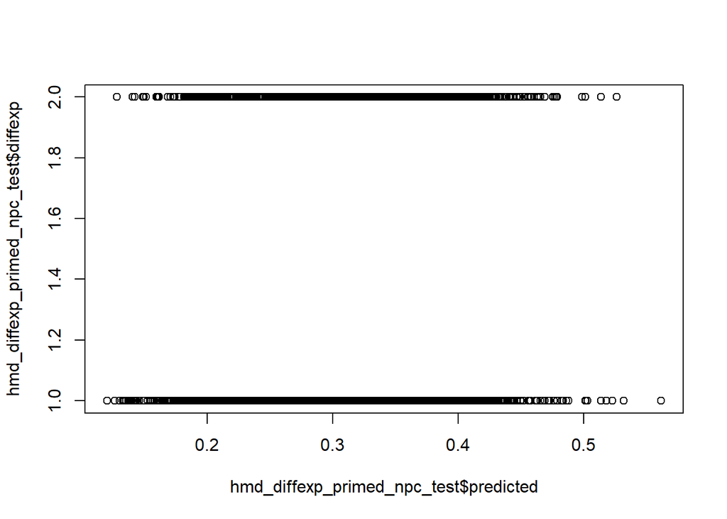

```r
set.seed(1209)

sample = sample.int(n = nrow(hmd_diffexp_primed_npc), size = floor(.7*nrow(hmd_diffexp_primed_npc)), replace = F)

hmd_diffexp_primed_npc_train = hmd_diffexp_primed_npc[sample,]
hmd_diffexp_primed_npc_test = hmd_diffexp_primed_npc[-sample,]

glm_k4_k27_logs_primed_npc_train = glm(diffexp ~ k4 + k27 + logk4 + logk27, data = hmd_diffexp_primed_npc_train, family = binomial)
glm_k4_k27_logs_primed_npc_trans_train = glm(diffexp ~ k4 + k27 + logk4 + logk27 + trans + logtrans, data = hmd_diffexp_primed_npc_train, family = binomial)
glm_k4_k27_logs_primed_npc_k9_train = glm(diffexp ~ k4 + k27 + logk4 + logk27 + k9, data = hmd_diffexp_primed_npc_train, family = binomial)

hmd_diffexp_primed_npc_test$predicted = predict(glm_k4_k27_logs_primed_npc_train, newdata = hmd_diffexp_primed_npc_test, type = "response")
hmd_diffexp_primed_npc_test$predicted_trans = predict(glm_k4_k27_logs_primed_npc_trans_train, newdata = hmd_diffexp_primed_npc_test, type = "response")
hmd_diffexp_primed_npc_test$predicted_k9 = predict(glm_k4_k27_logs_primed_npc_k9_train, newdata = hmd_diffexp_primed_npc_test, type = "response")

plot(x = hmd_diffexp_primed_npc_test$predicted, y = hmd_diffexp_primed_npc_test$diffexp)
```

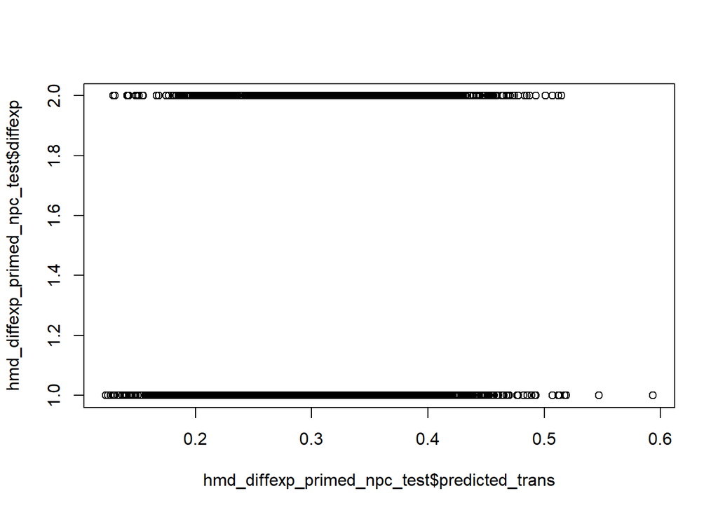

```r
plot(x = hmd_diffexp_primed_npc_test$predicted_trans, y = hmd_diffexp_primed_npc_test$diffexp)
```

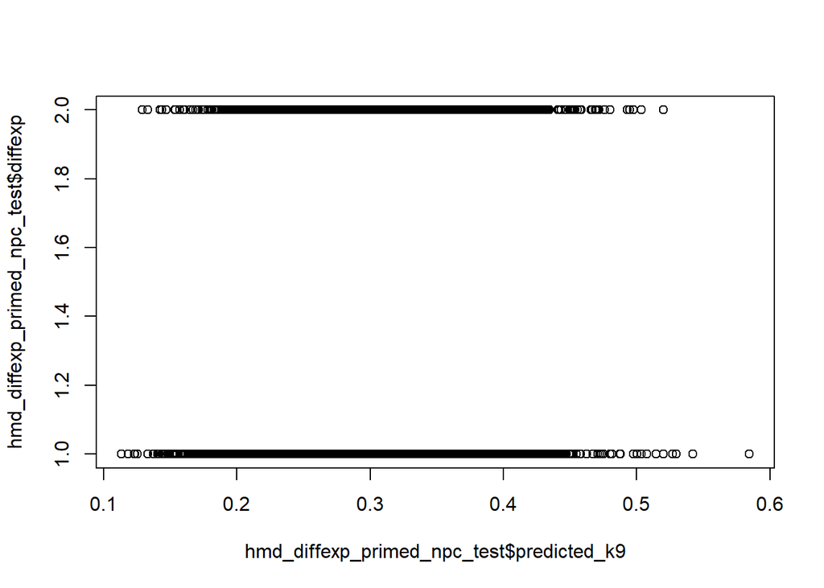

```r
plot(x = hmd_diffexp_primed_npc_test$predicted_k9, y = hmd_diffexp_primed_npc_test$diffexp)
```

```r
hmd_diffexp_primed_npc_test = hmd_diffexp_primed_npc_test %>% mutate(predicted_dir = ifelse(predicted>0.5, 1, 0), predicted_dir_trans = ifelse(predicted_trans>0.5, 1, 0), predicted_dir_k9 = ifelse(predicted_k9>0.5, 1, 0))

mean(0==hmd_diffexp_primed_npc_test$diffexp)
```

```
## [1] 0.668015
```

```r
mean(hmd_diffexp_primed_npc_test$predicted_dir==hmd_diffexp_primed_npc_test$diffexp)
```

```
## [1] 0.6672927
```

```r
mean(hmd_diffexp_primed_npc_test$predicted_dir_trans==hmd_diffexp_primed_npc_test$diffexp)
```

```
## [1] 0.6675816
```

```r
mean(hmd_diffexp_primed_npc_test$predicted_dir_k9==hmd_diffexp_primed_npc_test$diffexp)
```

```
## [1] 0.6668593
```

By the trivial model where we assume nothing is differentially expressed, we have a 66.8% accuracy rate. This rate is 66.73% with the model without trans, and 66.76% with the model with trans. Adding in k9 instead of trans and logtrans here brings the accuracy rate down to 66.69%.

Conclusion: bivalency does not provide us with more information about developmental staging of genes than do K4 and K27 alone.

# Fisher Hypergeometric Tests for Overlap

In this section, we will look for overlap with existing datasets.

First, we will look at the Mikkelsen, Xiao, and Mas bivalent genes as defined by ouranalysis et al., with overlap from -2.5kb to the end of the gene.